# Reddit_Analysis_2

## Analysis of reddit communities

- Downloaded https://files.pushshift.io/reddit/comments/ file from October 2018 (RC_2018-10) , File of comments on reddit
- There are 112 346 556 comments in the file
- Comments are a vital part of the reddit community, users commenting in a community is an important indicator of the users interest. These interactions can help the service provider to detect similar communities based on how users interact with communities.
- The objective of this analysis is to detect groups of subreddits that are implicitly related through how users comment.

```python
import pandas as pd
import matplotlib.pyplot as plt
import seaborn as sns
```

```python
import codecs
```

```python
import numpy as np
```

```python
import squarify
```

```python
from datetime import datetime
```

```python
from bokeh.plotting import figure, output_file, show, ColumnDataSource
from bokeh.models import HoverTool
```

```python
import bokeh.models as bmo
from bokeh.palettes import d3
```

```python
from bokeh.io import output_notebook
```

```python
%matplotlib inline
```

```python
output_notebook()
```

```python
plt.rcParams['figure.figsize']=(20,10)
```

```python
df_comments_iter=pd.read_json(codecs.open('./data/RC_filtered.json','r','utf-8'), orient='records', lines=True, chunksize=1000000)
```

```python
dict_authors={}
```

```python
df_interactions=None
```

```python
times=0
for df_temp in df_comments_iter:

    del df_temp['text']
    df_elems=df_temp[['author', 'author_created_utc', 'controversiality', 'created','subreddit']]
    if df_interactions is None:
        df_interactions=df_elems
    else:
        df_interactions=pd.concat([df_interactions,df_elems])
    df_temp=df_temp[~df_temp.author_created_utc.isna()]
    dict_df=pd.Series(df_temp.author_created_utc.values, index=df_temp.author)
    times+=1
    dict_authors.update(dict_df.to_dict())
```

```python
df_interactions.shape
```

```
(112346556, 5)
```

```python
dict_authors['Tack22']
```

```
1376831517.0
```

```python
#df_interactions=pd.read_pickle('./data/interactions.pkl')
df_interactions.to_pickle('./data/interactions.pkl')
```

```python
df_interactions.head()
```

|  | author | author_created_utc | controversiality | created | subreddit |
| --- | --- | --- | --- | --- | --- |
| 0 | TistedLogic | 1.312616e+09 | 0 | 1538352000 | Unexpected |
| 1 | misssaladfingers | 1.536865e+09 | 0 | 1538352000 | insomnia |
| 2 | Increase_Vitality | 1.467817e+09 | 0 | 1538352000 | pics |
| 3 | volkanize | 1.531799e+09 | 0 | 1538352000 | NoStupidQuestions |
| 4 | [deleted] | NaN | 0 | 1538352000 | steroids |

```python
df_interactions.tail()
```

[output not shown]

### Interactions come from October 2018

```python
str(datetime.utcfromtimestamp(df_interactions.created.min()))
```

```
'2018-10-01 00:00:00'
```

```python
str(datetime.utcfromtimestamp(df_interactions.created.max()))
```

```
'2018-10-31 23:59:59'
```

### Remove interactions that are in user's pages, not subreddits, they start with u_

```python
df_interactions=df_interactions[~df_interactions.subreddit.str.startswith('u_')]
```

```python
df_interactions.shape
```

```
(112183892, 5)
```

### At first glance, it makes sense that the subreddits that have most of the interactions are the ones that are oriented to conversation, being AskReddit the main example, however a closer exploration of the dataset is needed in order to see if all the comments should count in order to see how subreddits are related to one another

```python
df_interactions.subreddit.value_counts().head(20)
```

```
AskReddit            5834042
politics             2208780
nfl                  1285725
The_Donald           1207555
funny                 999457
fantasyfootball       956079
nba                   902452
leagueoflegends       886118
CFB                   882986
worldnews             834164
FortNiteBR            799807
news                  758534
pics                  717980
AskOuija              714345
gaming                693736
Blackops4             606413
soccer                586826
baseball              578326
reddeadredemption     561949
dankmemes             560701
Name: subreddit, dtype: int64
```

```python
df_interactions.subreddit.value_counts().describe()
```

```
count    9.021100e+04
mean     1.243572e+03
std      2.573212e+04
min      1.000000e+00
25%      2.000000e+00
50%      8.000000e+00
75%      6.000000e+01
max      5.834042e+06
Name: subreddit, dtype: float64
```

### Im going to explore how users participate in the communities, first I'm going to aggregate by author, so I can see how authors behave in the website

```python
df_gp_author=df_interactions.groupby('author')
```

```python
grouped_author=df_gp_author.agg({'author':'count','subreddit':set, 'author_created_utc': min, 'controversiality': np.mean })
```

```python
del df_interactions['author_created_utc']
```

```python
del df_interactions['controversiality']
```

```python
grouped_author.rename(columns={'author':'count_times'},inplace=True)
```

```python
grouped_author['how_many_subs']=grouped_author.apply(lambda row: len(row['subreddit']),axis=1)
```

```python
grouped_author.describe()
```

|  | count_times | author_created_utc | controversiality | how_many_subs |
| --- | --- | --- | --- | --- |
| count | 5.300633e+06 | 5.300627e+06 | 5.300633e+06 | 5.300633e+06 |
| mean | 2.116424e+01 | 1.459184e+09 | 1.509137e-02 | 4.262493e+00 |
| std | 3.471241e+03 | 7.418161e+07 | 7.436195e-02 | 2.076277e+01 |
| min | 1.000000e+00 | 1.118030e+09 | 0.000000e+00 | 1.000000e+00 |
| 25% | 1.000000e+00 | 1.408808e+09 | 0.000000e+00 | 1.000000e+00 |
| 50% | 4.000000e+00 | 1.481490e+09 | 0.000000e+00 | 2.000000e+00 |
| 75% | 1.300000e+01 | 1.522193e+09 | 0.000000e+00 | 4.000000e+00 |
| max | 7.908740e+06 | 1.541030e+09 | 1.000000e+00 | 4.024600e+04 |

### At least 5.3 Million users made comments during the period of analysis, an important part of the interactions correspond to deleted comments and reddit's AutoModerator bot. It's surprising to find out the number of deleted comments (177 per minute, almost 3 per second).

```python
#The most prolific authors are bots
grouped_author.sort_values(by='count_times',ascending=False).head(30)
```

| author | count_times | subreddit | author_created_utc | controversiality | how_many_subs |
| --- | --- | --- | --- | --- | --- |
| [deleted] | 7908740 | {startrek, RateMyNudeBody, weatherfactory, DEG... | NaN | 0.026830 | 40246 |
| AutoModerator | 1119464 | {startrek, xboxone, Kyra_Santoro, DBZDokkanMar... | 1.325741e+09 | 0.002046 | 5746 |
| MemeInvestor_bot | 158619 | {MemeEconomy} | 1.526661e+09 | 0.000038 | 1 |
| transcribot | 72411 | {TranscribersOfReddit} | 1.493751e+09 | 0.000000 | 1 |
| request_bot | 57730 | {redditrequest} | 1.341186e+09 | 0.000000 | 1 |
| KeepingDankMemesDank | 50705 | {dankmemes} | 1.520156e+09 | 0.025244 | 1 |
| transcribersofreddit | 41278 | {TranscribersOfReddit} | 1.490756e+09 | 0.000000 | 1 |
| MTGCardFetcher | 31186 | {LavaSpike, hardenedscales, EDH, FishMTG, spik... | 1.396613e+09 | 0.000096 | 69 |
| CommonMisspellingBot | 28507 | {haskellquestions, RateMyNudeBody, DEG, vuejs,... | 1.488799e+09 | 0.084190 | 7770 |
| imguralbumbot | 28435 | {Airmailreddit, Paladins_Porn, NetsuiteAdmin, ... | 1.494883e+09 | 0.001477 | 7037 |
| DRTGGF | 24098 | {TheWalkingDeadS9, UFC229Live2018, Week5NFLGam... | 1.528975e+09 | 0.000000 | 3 |
| HayatRahal | 23322 | {nflstreamhd_} | 1.499235e+09 | 0.000000 | 1 |
| TotesMessenger | 23275 | {AnsalonMUD, RateMyNudeBody, ManjaroLinux, vue... | 1.421290e+09 | 0.006273 | 6749 |
| Robert_Stokes | 19038 | {Live_TV_Hd, soccerstreams, Streambyreddit, ch... | 1.534347e+09 | 0.000000 | 5 |
| sneakpeekbot | 17392 | {lesdom, regularcarreviews, IndoorGarden, Stra... | 1.483197e+09 | 0.005807 | 4526 |
| SnapshillBot | 17125 | {BadEverything, GenderCynical, Buttcoin, baduk... | 1.420514e+09 | 0.002803 | 54 |
| BooCMB | 16443 | {haskellquestions, RateMyNudeBody, DEG, vuejs,... | 1.539237e+09 | 0.067202 | 5937 |
| WikiTextBot | 15890 | {regularcarreviews, IndoorGarden, SGU, Anthrop... | 1.496577e+09 | 0.002014 | 3733 |
| timezone_bot | 15571 | {regularcarreviews, NADDPODLeague, nbaliveulti... | 1.495052e+09 | 0.001798 | 1700 |
| GarlicoinAccount | 14473 | {pic, Rainier, waterporn, winterporn, Woodland... | 1.516661e+09 | 0.000069 | 49 |
| NFCAAOfficialRefBot | 13480 | {FakeCollegeFootball} | 1.518057e+09 | 0.000000 | 1 |
| hwsbot | 13382 | {hardwareswap} | 1.380393e+09 | 0.000000 | 1 |
| Bot_Metric | 12798 | {Fluidacrylics, IndoorGarden, AnnieRuth, Leath... | 1.525002e+09 | 0.002188 | 4457 |
| ClickableLinkBot | 11747 | {regularcarreviews, IndoorGarden, Straps, Anth... | 1.503784e+09 | 0.002979 | 3348 |
| wannabeedgynigga | 11384 | {PewdiepieSubmissions, comedyheaven, DokiDokiR... | 1.532869e+09 | 0.000088 | 14 |
| Roboragi | 11274 | {NLSSCircleJerk, ecchi, animenocontext, Backgr... | 1.435148e+09 | 0.000355 | 100 |
| B0tRank | 11138 | {IndoorGarden, edmproduction, Habs, Hitomi_Tan... | 1.534110e+09 | 0.019662 | 3812 |
| TiltedTowersBot | 10832 | {FortNiteBR} | 1.534373e+09 | 0.000000 | 1 |
| swack_ | 9516 | {TwoBestFriendsPlay, CxTV, KotakuInAction, Cri... | 1.506364e+09 | 0.000000 | 4 |
| SteamKiwi | 9280 | {playnewz, RimWorld, PuppyChefAcademy, Oxygenn... | 1.495644e+09 | 0.000000 | 13 |

```python
#Bots are the authors that visit most
grouped_author.sort_values(by='how_many_subs',ascending=False).head(30)
```

| author | count_times | subreddit | author_created_utc | controversiality | how_many_subs |
| --- | --- | --- | --- | --- | --- |
| [deleted] | 7908740 | {startrek, RateMyNudeBody, weatherfactory, DEG... | NaN | 0.026830 | 40246 |
| CommonMisspellingBot | 28507 | {haskellquestions, RateMyNudeBody, DEG, vuejs,... | 1.488799e+09 | 0.084190 | 7770 |
| imguralbumbot | 28435 | {Airmailreddit, Paladins_Porn, NetsuiteAdmin, ... | 1.494883e+09 | 0.001477 | 7037 |
| TotesMessenger | 23275 | {AnsalonMUD, RateMyNudeBody, ManjaroLinux, vue... | 1.421290e+09 | 0.006273 | 6749 |
| BooCMB | 16443 | {haskellquestions, RateMyNudeBody, DEG, vuejs,... | 1.539237e+09 | 0.067202 | 5937 |
| AutoModerator | 1119464 | {startrek, xboxone, Kyra_Santoro, DBZDokkanMar... | 1.325741e+09 | 0.002046 | 5746 |
| sneakpeekbot | 17392 | {lesdom, regularcarreviews, IndoorGarden, Stra... | 1.483197e+09 | 0.005807 | 4526 |
| Bot_Metric | 12798 | {Fluidacrylics, IndoorGarden, AnnieRuth, Leath... | 1.525002e+09 | 0.002188 | 4457 |
| B0tRank | 11138 | {IndoorGarden, edmproduction, Habs, Hitomi_Tan... | 1.534110e+09 | 0.019662 | 3812 |
| WikiTextBot | 15890 | {regularcarreviews, IndoorGarden, SGU, Anthrop... | 1.496577e+09 | 0.002014 | 3733 |
| ClickableLinkBot | 11747 | {regularcarreviews, IndoorGarden, Straps, Anth... | 1.503784e+09 | 0.002979 | 3348 |
| Link-Help-Bot | 6442 | {regularcarreviews, IndoorGarden, Lexus, edmpr... | 1.536533e+09 | 0.081962 | 3320 |
| RemindMeBot | 9237 | {IndoorGarden, edmproduction, Habs, Geniva_, t... | 1.398586e+09 | 0.001083 | 2857 |
| HelperBot_ | 7332 | {AnnArbor, regularcarreviews, IndoorGarden, ed... | 1.437288e+09 | 0.002728 | 2255 |
| gifv-bot | 6091 | {Harleereed28, ShemalesTenting, Hitomi_Tanaka,... | 1.449157e+09 | 0.000328 | 2168 |
| YTubeInfoBot | 4487 | {edmproduction, auckland, ManjaroLinux, xboxon... | 1.526780e+09 | 0.004234 | 1933 |
| PORTMANTEAU-BOT | 4000 | {regularcarreviews, Duklock, Lexus, Marriage, ... | 1.494439e+09 | 0.014000 | 1917 |
| anti-gif-bot | 5634 | {Duklock, MinecraftCommands, OlsenXPlaza, inca... | 1.491757e+09 | 0.004437 | 1850 |
| amp-is-watching-you | 4476 | {AnnArbor, regularcarreviews, ForHonorRants, M... | 1.534176e+09 | 0.003351 | 1752 |
| MaxImageBot | 4489 | {Honkers, RateMyNudeBody, Guiltygear, xboxone,... | 1.518727e+09 | 0.001114 | 1727 |
| timezone_bot | 15571 | {regularcarreviews, NADDPODLeague, nbaliveulti... | 1.495052e+09 | 0.001798 | 1700 |
| misspellbot | 3187 | {edmproduction, ForHonorRants, Habs, TheMonkey... | 1.537896e+09 | 0.096956 | 1591 |
| LimbRetrieval-Bot | 3030 | {regularcarreviews, IndoorGarden, Airmailreddi... | 1.516263e+09 | 0.022442 | 1576 |
| GoodBotBadAdmins | 4242 | {TheMonkeysPaw, RateMyNudeBody, xboxone, Jiggl... | 1.540510e+09 | 0.032768 | 1498 |
| thank_mr_skeltal_bot | 8292 | {edmproduction, TheMonkeysPaw, step1, infp, br... | 1.470648e+09 | 0.008080 | 1481 |
| AreYouDeaf | 3090 | {edmproduction, TheMonkeysPaw, RateMyNudeBody,... | 1.513178e+09 | 0.031068 | 1436 |
| phonebatterylevelbot | 2553 | {regularcarreviews, Duklock, Habs, Geniva_, Ti... | 1.471836e+09 | 0.046612 | 1369 |
| BigLebowskiBot | 2716 | {IndoorGarden, edmproduction, tretinoin, infp,... | 1.429849e+09 | 0.029823 | 1310 |
| vReddit_Player_Bot | 6443 | {DungeonsAndDragons, mothmemes, Habs, scripted... | 1.536826e+09 | 0.006053 | 1224 |
| auto-xkcd37 | 2112 | {RPGdesign, ufc, ForHonorRants, TheMonkeysPaw,... | 1.506314e+09 | 0.011837 | 1179 |

### Let's find out where the deleted interactions are.

##### At fitst glance and as expected, larger subreddits have many deleted comments. I'm going to compare the amount of deleted comments vs the amount of total comments. In order to not bias the analysis by the size of the community, I'm going to calculate the lower bound of the confidence interval using the [Binomial proportion confidence inteval](https://en.wikipedia.org/wiki/Binomial_proportion_confidence_interval) to report the communities that delete comparatively more comments p-value (0.05)

```python
deleted_interactions_grouped=df_interactions[df_interactions.author=='[deleted]'].groupby('subreddit').agg({'author':'count'})
```

```python
deleted_interactions_grouped=deleted_interactions_grouped.join(pd.DataFrame(df_interactions.subreddit.value_counts())).fillna(0)
```

```python
deleted_interactions_grouped.rename(inplace=True, columns={'author':'deleted_comments', 'subreddit':'total_comments'})
```

```python
deleted_interactions_grouped['proportion']=deleted_interactions_grouped['deleted_comments']/deleted_interactions_grouped['total_comments']
```

```python
from statsmodels.stats.proportion import proportion_confint
```

```python
deleted_interactions_grouped['proportion_low']=deleted_interactions_grouped.apply(lambda row: proportion_confint(row['deleted_comments'], row['total_comments'])[0], axis=1)
```

```python
deleted_interactions_grouped.sort_values(by='deleted_comments', ascending=False).head(20)
```

| subreddit | deleted_comments | total_comments | proportion | proportion_low |
| --- | --- | --- | --- | --- |
| AskReddit | 356833 | 5834042 | 0.061164 | 0.060969 |
| politics | 289434 | 2208780 | 0.131038 | 0.130593 |
| news | 148571 | 758534 | 0.195866 | 0.194973 |
| The_Donald | 97062 | 1207555 | 0.080379 | 0.079894 |
| worldnews | 83370 | 834164 | 0.099944 | 0.099301 |
| funny | 65153 | 999457 | 0.065188 | 0.064704 |
| nfl | 63521 | 1285725 | 0.049405 | 0.049030 |
| leagueoflegends | 62995 | 886118 | 0.071091 | 0.070556 |
| AskOuija | 62899 | 714345 | 0.088051 | 0.087394 |
| gonewild | 62726 | 449920 | 0.139416 | 0.138404 |
| nba | 59119 | 902452 | 0.065509 | 0.064999 |
| science | 58350 | 128346 | 0.454630 | 0.451906 |
| pics | 52204 | 717980 | 0.072710 | 0.072109 |
| TwoXChromosomes | 49432 | 124460 | 0.397172 | 0.394453 |
| MMA | 48579 | 519218 | 0.093562 | 0.092770 |
| fantasyfootball | 47059 | 956079 | 0.049221 | 0.048787 |
| reddeadredemption | 46633 | 561949 | 0.082984 | 0.082263 |
| relationships | 42888 | 279462 | 0.153466 | 0.152130 |
| CFB | 41047 | 882986 | 0.046487 | 0.046047 |
| soccer | 39481 | 586826 | 0.067279 | 0.066638 |

### Many subreddits delete all their comments (2568), most of them seem to be for sharing live tv events

```python
deleted_interactions_grouped[deleted_interactions_grouped.proportion_low==1].sort_values(by='total_comments', ascending=False).head(30)
```

| subreddit | deleted_comments | total_comments | proportion | proportion_low |
| --- | --- | --- | --- | --- |
| nfltodaygames | 19676 | 19676 | 1.0 | 1.0 |
| UFC230Liv | 17591 | 17591 | 1.0 | 1.0 |
| BroncosCardinalsLive | 12274 | 12274 | 1.0 | 1.0 |
| SaintsVikingsLivee | 7261 | 7261 | 1.0 | 1.0 |
| UFC229LiveHD | 6334 | 6334 | 1.0 | 1.0 |
| EaglesJaguarsLives | 5921 | 5921 | 1.0 | 1.0 |
| NFLweekupdate | 5217 | 5217 | 1.0 | 1.0 |
| NFLusa | 5205 | 5205 | 1.0 | 1.0 |
| ColtsJetsLive | 4618 | 4618 | 1.0 | 1.0 |
| ChargersBrownsLive | 3939 | 3939 | 1.0 | 1.0 |
| livesports_tv_ | 3001 | 3001 | 1.0 | 1.0 |
| PanthersvsEaglesLive | 2856 | 2856 | 1.0 | 1.0 |
| TitansvsBillsLives | 2808 | 2808 | 1.0 | 1.0 |
| CrawfordBenavidezLive | 2475 | 2475 | 1.0 | 1.0 |
| DolphinsvsTexansLives | 2423 | 2423 | 1.0 | 1.0 |
| RamsBroncosLives | 2410 | 2410 | 1.0 | 1.0 |
| DolphinsBengalsLive | 2356 | 2356 | 1.0 | 1.0 |
| PatriotsvsChiefsLives | 2329 | 2329 | 1.0 | 1.0 |
| updateNFL | 2164 | 2164 | 1.0 | 1.0 |
| RaidersvSeahawksLive | 2115 | 2115 | 1.0 | 1.0 |
| DolphinsTexansLives | 2101 | 2101 | 1.0 | 1.0 |
| BenavidezCrawfordlive | 2048 | 2048 | 1.0 | 1.0 |
| w6EaglesvsGiants | 1943 | 1943 | 1.0 | 1.0 |
| SoccerLiveStreamHD | 1636 | 1636 | 1.0 | 1.0 |
| LionsvsDolphinsLive | 1523 | 1523 | 1.0 | 1.0 |
| STREAMSNCAA | 1505 | 1505 | 1.0 | 1.0 |
| UEFAChampionsLeague4K | 1492 | 1492 | 1.0 | 1.0 |
| PatriotsvsBearsLives | 1464 | 1464 | 1.0 | 1.0 |
| TexansJaguarsLives | 1421 | 1421 | 1.0 | 1.0 |
| SaintsvsRavensLive | 1420 | 1420 | 1.0 | 1.0 |

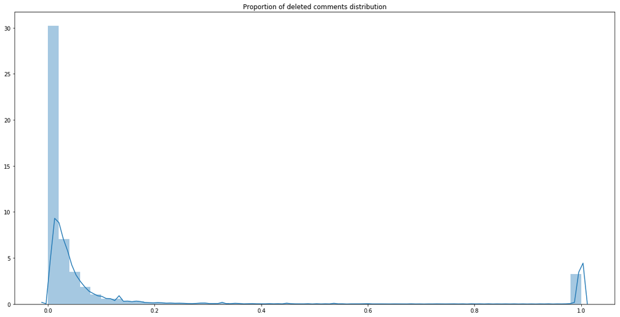

```python
sns.distplot(deleted_interactions_grouped['proportion_low'].values)
plt.title("Proportion of deleted comments distribution")
```

### After removing the subreddits that delete all their comments (proportion is 1), other subreddits that delete most of their comments they seem to be similar to the ones identified beforehand

```python
deleted_interactions_grouped[deleted_interactions_grouped.proportion_low!=1].sort_values(by='proportion_low', ascending=False).head(10)
```

| subreddit | deleted_comments | total_comments | proportion | proportion_low |
| --- | --- | --- | --- | --- |
| SoCcErs4k | 10927 | 10928 | 0.999908 | 0.999729 |
| liveTvUs | 23853 | 23857 | 0.999832 | 0.999668 |
| BillsColtsLive | 8184 | 8185 | 0.999878 | 0.999638 |
| ufc230livehd | 22310 | 22317 | 0.999686 | 0.999454 |
| ChargersTitansLive | 8028 | 8030 | 0.999751 | 0.999406 |
| ChiefsPatriotsLivess | 4523 | 4524 | 0.999779 | 0.999346 |
| BearsDolphinsLive | 4119 | 4120 | 0.999757 | 0.999282 |
| BuccaneersFalconsLive | 4102 | 4103 | 0.999756 | 0.999279 |
| Gamenfllivehd | 7201 | 7204 | 0.999584 | 0.999112 |
| NCAAFootball18 | 12841 | 12851 | 0.999222 | 0.998740 |

### A scatterplot between the proportion and the total of comments helps us to understand the relationship between them, for the largest communities

I will apply k-means clustering to discover groups od subreddits based on their total ammount of comments and deletion rate

```python
filtered=deleted_interactions_grouped[deleted_interactions_grouped.total_comments>2000]
```

```python
filtered.shape
```

```
(4654, 4)
```

```python
filtered.nlargest(20, columns=['proportion_low','total_comments'])
```

| subreddit | deleted_comments | total_comments | proportion | proportion_low |
| --- | --- | --- | --- | --- |
| nfltodaygames | 19676 | 19676 | 1.0 | 1.0 |
| UFC230Liv | 17591 | 17591 | 1.0 | 1.0 |
| BroncosCardinalsLive | 12274 | 12274 | 1.0 | 1.0 |
| SaintsVikingsLivee | 7261 | 7261 | 1.0 | 1.0 |
| UFC229LiveHD | 6334 | 6334 | 1.0 | 1.0 |
| EaglesJaguarsLives | 5921 | 5921 | 1.0 | 1.0 |
| NFLweekupdate | 5217 | 5217 | 1.0 | 1.0 |
| NFLusa | 5205 | 5205 | 1.0 | 1.0 |
| ColtsJetsLive | 4618 | 4618 | 1.0 | 1.0 |
| ChargersBrownsLive | 3939 | 3939 | 1.0 | 1.0 |
| livesports_tv_ | 3001 | 3001 | 1.0 | 1.0 |
| PanthersvsEaglesLive | 2856 | 2856 | 1.0 | 1.0 |
| TitansvsBillsLives | 2808 | 2808 | 1.0 | 1.0 |
| CrawfordBenavidezLive | 2475 | 2475 | 1.0 | 1.0 |
| DolphinsvsTexansLives | 2423 | 2423 | 1.0 | 1.0 |
| RamsBroncosLives | 2410 | 2410 | 1.0 | 1.0 |
| DolphinsBengalsLive | 2356 | 2356 | 1.0 | 1.0 |
| PatriotsvsChiefsLives | 2329 | 2329 | 1.0 | 1.0 |
| updateNFL | 2164 | 2164 | 1.0 | 1.0 |
| RaidersvSeahawksLive | 2115 | 2115 | 1.0 | 1.0 |

```python
from sklearn.preprocessing import RobustScaler
scaler = RobustScaler()
```

```python
X=scaler.fit_transform(filtered[['total_comments','proportion_low']])
```

```python
X
```

```
array([[-0.16643772, -0.04201841],
       [-0.26206408, -0.57110206],
       [ 1.02441618, -0.39124515],
       ...,
       [ 2.1589046 ,  2.53292994],
       [ 0.31878407,  0.99990535],
       [-0.21589046, -0.70547795]])
```

```python
from sklearn.cluster import KMeans
```

```python
# Run k-means for coloring identified groups
labels = KMeans(init='k-means++', n_clusters=6).fit_predict(X)
```

```python
len(np.unique(labels))
```

```
6
```

```python
palette = d3['Category10'][len(np.unique(labels))]
```

```python
colors = [palette[x] for x in labels]
```

```python
source = ColumnDataSource(
        data=dict(
            x=filtered['total_comments'],
            y=filtered['proportion_low'],
            desc=filtered.index,
            label=labels,
            colors=colors
        )
    )
```

```python
hover = HoverTool(
        tooltips=[
            ("index", "$index"),
            ("(x,y)", "($x, $y)"),
             ("group", "@label"),
            ("desc", "@desc"),
        ]
    )
```

```python
p = figure(plot_width=1000, plot_height=500, x_axis_type="log", tools=[hover], title="Total comments vs proportion of deleted comments (lower bound estimation)")
```

### Groups analysis (Hover to view the subreddits name)

- Group 1 (orange) only has AskReddit, the biggest subreddit in terms of comments and with similar rates of deleted comments when compared to comparable communities.
- Group 3 (red) has the next largest subreddit: Politics, with a similar deletion rate
- Group 2 (green) has other big subreddits, from this group news stands out, deleting almost 20% of their comments.
- Group 5 (brown) starts to show instances with larger rates of deleted comments, TwoXChromosomes and science delete around 40% of their comments.
- Group 4 (purple) encompasses the subreddits where more than half of the comments were deleted, the largest communities of this group are photoshopbattles and play4k, play4k is an streaming subreddit with a 90% deletion rate
- Group 0 (blue) has the rest of the subreddits, not as much participation and not as much deletion rate

```python
p.scatter('x', 'y', size=8, source=source, fill_color='colors')
show(p)
```

[interactive chart not shown]

```python
del source
```

```python
filtered['label']=labels
```

```python
filtered_g4=filtered[filtered.label==4]
```

```python
filtered_g4.nlargest(15, columns=['total_comments','proportion_low'])
```

| subreddit | deleted_comments | total_comments | proportion | proportion_low | label |
| --- | --- | --- | --- | --- | --- |
| Play4K | 34741 | 37526 | 0.925785 | 0.923133 | 4 |
| photoshopbattles | 18227 | 34688 | 0.525455 | 0.520201 | 4 |
| liveTvUs | 23853 | 23857 | 0.999832 | 0.999668 | 4 |
| ufc230livehd | 22310 | 22317 | 0.999686 | 0.999454 | 4 |
| nfltodaygames | 19676 | 19676 | 1.000000 | 1.000000 | 4 |
| UFC230Liv | 17591 | 17591 | 1.000000 | 1.000000 | 4 |
| nflgamesday | 17280 | 17332 | 0.997000 | 0.996186 | 4 |
| sportsonlinetv | 13392 | 13429 | 0.997245 | 0.996358 | 4 |
| NCAAFootball18 | 12841 | 12851 | 0.999222 | 0.998740 | 4 |
| LIVENFL2018Game | 12525 | 12586 | 0.995153 | 0.993940 | 4 |
| GiantsFalconsLive | 12498 | 12527 | 0.997685 | 0.996843 | 4 |
| BroncosCardinalsLive | 12274 | 12274 | 1.000000 | 1.000000 | 4 |
| SoCcErs4k | 10927 | 10928 | 0.999908 | 0.999729 | 4 |
| ABCC | 8932 | 9558 | 0.934505 | 0.929545 | 4 |
| ufc229livehq | 9242 | 9305 | 0.993229 | 0.991563 | 4 |

### Let's do an analysis of the names of the subreddits of this group 4 to confirm that these are the communities for streaming live events

Grant Jenks' [wordsegment](http://www.grantjenks.com/docs/wordsegment/api.html) library can help in this taks by splitting the subreddits' names

```python
from wordsegment import load, segment
load()
```

```python
words_series=filtered_g4.index.map(lambda x: list(wordsegment.segment(str.lower(x))))
```

```python
flatten_words = lambda l: [item for sublist in l for item in sublist]
```

```python
word_freq=pd.DataFrame(np.array(np.unique( flatten_words(words_series), return_counts=True)).T, columns=['word','freq'])
word_freq['freq']=word_freq['freq'].astype(int)
```

### As seen by the word frequency, live, tv and nfl team names are prevalent in this period of time for this subreddits

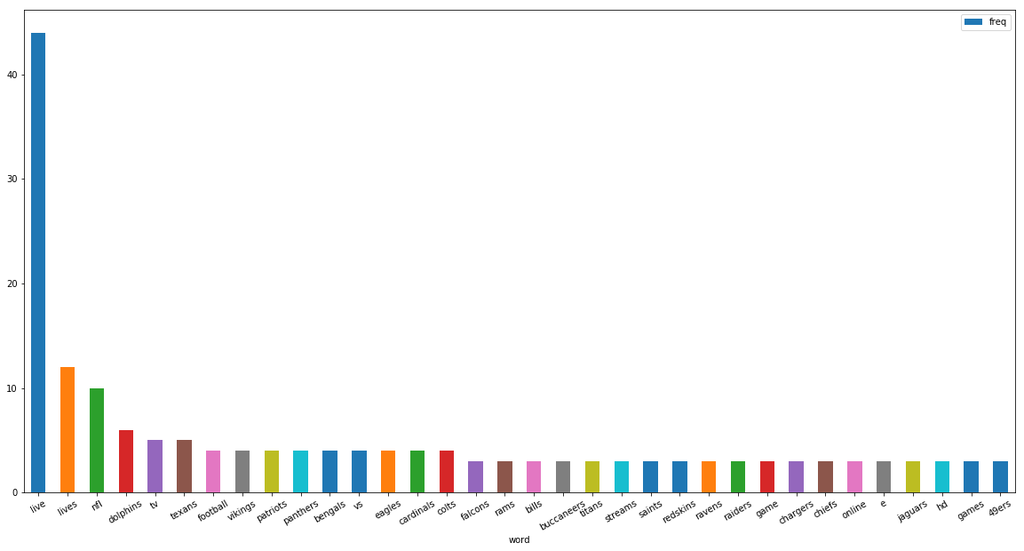

```python
word_freq[word_freq.freq>2].sort_values(by='freq', ascending=False).plot.bar(x='word', y='freq', rot=30)
```

### In the first version of this analysis I had removed all deleted comments, now the filtered_g4 dataframe contains one group of similar subreddits

```python
del word_freq
del flatten_words
del load, segment
```

```python
del words_series
```

```python
del filtered
```

```python
del deleted_interactions_grouped
```

```python
df_interactions.shape
```

```
(112183892, 4)
```

```python
df_interactions=df_interactions[df_interactions.author!='[deleted]']
```

```python
df_interactions.shape
```

```
(104275152, 4)
```

```python
grouped_author.drop('[deleted]',axis=0, inplace=True)
```

### One way to consider two subreddits similar its by users co-commenting, I'm going to remove all comments from users that only comment in one subreddit, almost 50% of all users only have commented on one subreddit

```python
grouped_author[grouped_author.how_many_subs==1].index
```

```
Index(['*polhold00214', '------------------O', '----------_-_', '-------_---',
       '-------jem', '------J------', '------MJ------', '------____--',
       '-----60-09', '-----NSA-----',
       ...
       'zzzzzzarah', 'zzzzzzgrt', 'zzzzzzp0', 'zzzzzzzssz', 'zzzzzzzzaakjs',
       'zzzzzzzzki', 'zzzzzzzztrewq', 'zzzzzzzzzx', 'zzzzzzzzzzninja',
       'zzzzzzzzzzzzzddq'],
      dtype='object', name='author', length=2325909)
```

```python
df_interactions=df_interactions[~df_interactions.author.isin(grouped_author[grouped_author.how_many_subs==1].index)]
```

```python
df_interactions.shape
```

```
(95444921, 4)
```

```python
grouped_author=grouped_author[grouped_author.how_many_subs>1]
```

```python
grouped_author.shape
```

```
(2974723, 5)
```

```python
top_200_authors=grouped_author.nlargest(n=200, columns='count_times').reset_index()
```

### AutoModerator is another bot that has a lot of interactions, since its a tool that subreddit admins use to help them monitor their subreddits

It has as many comments as the next 199 users, its not relevant for the study so I will remove it

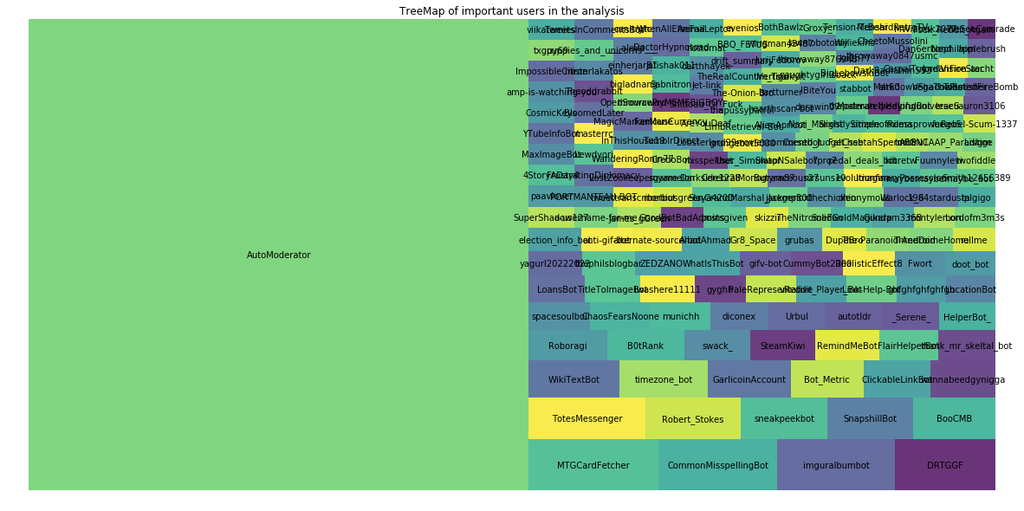

```python
squarify.plot(sizes=top_200_authors['count_times'], label=top_200_authors['author'], alpha=.8)
plt.axis('off')
plt.title("TreeMap of important users in the analysis")
plt.show()
```

```python
grouped_author.drop('AutoModerator',axis=0, inplace=True)
```

```python
df_interactions=df_interactions[df_interactions.author!='AutoModerator']
```

```python
df_interactions.shape
```

```
(94325457, 3)
```

```python
grouped_author.to_pickle('./data/grouped_temp.pickle')
```

```python
df_interactions.to_pickle('./data/df_interactions_temp.pickle')
```

```python
filtered_g4.to_pickle('./data/df_filteredg4.pickle')
```

```python
del top_200_authors
```

### There's still a lot of interactions that come from bots. I'll try to identify them in order to only keep the interactions of real users, I'm going to extract features to detect bots

- Detect if it has bot in their name
- Is the author commenting on many subreddits
- Is it commenting on very brief timespans

```python
def diff_stats(series):
    s=series.sort_values().diff().dropna()
    return (s.mean(),s.min(),s.std())
```

```python
grouped_ext=df_interactions[df_interactions.author.isin(grouped_author.index)].groupby('author').agg({'created':diff_stats})
```

```python
grouped_ext['created_mean']=grouped_ext['created'].apply(lambda x: x[0])
```

```python
grouped_ext['created_min']=grouped_ext['created'].apply(lambda x: x[1])
```

```python
grouped_ext['created_std']=grouped_ext['created'].apply(lambda x: x[2])
```

```python
del grouped_ext['created']
```

```python
grouped_ext.head()
```

| author | created_mean | created_min | created_std |
| --- | --- | --- | --- |
| -------------------7 | 227741.454545 | 40232.0 | 259740.089393 |
| -------------------c | 81984.933333 | 21.0 | 152279.058999 |
| -------------------x | 169598.500000 | 445.0 | 239219.173823 |
| ---------------h | 178338.800000 | 162.0 | 312234.153151 |
| -----------0 | 219462.625000 | 94.0 | 414214.024567 |

```python
# Users that have 'bot' in their name
from wordsegment import load, segment
load()
```

```python
grouped_author['separated']=grouped_author.index.map(lambda x: set(segment(str.lower(x))))
```

```python
grouped_author['has_bot']=grouped_author['separated'].apply(lambda x : 'bot' in x or 'bots' in x)
```

```python
grouped_author['has_bot']=  (grouped_author['has_bot']==True) | (grouped_author.index.map(lambda x: "b0t" in str.lower(x)).values)
```

```python
grouped_author['high_count']=grouped_author['count_times']>=1489
```

```python
grouped_author=grouped_author.join(grouped_ext)
```

```python
grouped_author.sort_values(by='count_times', ascending=False).head(100)
```

| author | count_times | subreddit | author_created_utc | controversiality | how_many_subs | separated | has_bot | high_count | created_mean | created_min | created_std |
| --- | --- | --- | --- | --- | --- | --- | --- | --- | --- | --- | --- |
| MTGCardFetcher | 31186 | {shittyjudgequestions, HollowKnightMemes, Gobl... | 1.396613e+09 | 0.000096 | 69 | {fetcher, card, mtg} | False | True | 85.885265 | 0.0 | 106.408909 |
| CommonMisspellingBot | 28507 | {xfce, masturbationquestions, BotsScrewingUp, ... | 1.488799e+09 | 0.084190 | 7770 | {bot, common, misspelling} | True | True | 93.949975 | 0.0 | 109.249102 |
| imguralbumbot | 28435 | {Dirtbikes, DelawareOH, AnimalRights, TheGreat... | 1.494883e+09 | 0.001477 | 7037 | {bot, img, album, ur} | True | True | 94.190793 | 0.0 | 146.845121 |
| DRTGGF | 24098 | {TheWalkingDeadS9, Week5NFLGameLive, UFC229Liv... | 1.528975e+09 | 0.000000 | 3 | {drt, ggf} | False | True | 31.516662 | 0.0 | 4260.546727 |
| TotesMessenger | 23275 | {Dirtbikes, manhwa, AnimalRights, army, missm3... | 1.421290e+09 | 0.006273 | 6749 | {messenger, totes} | False | True | 115.063032 | 0.0 | 268.795085 |
| Robert_Stokes | 19038 | {soccerstreams, Streambyreddit, championsleagu... | 1.534347e+09 | 0.000000 | 5 | {robert, stokes} | False | True | 113.404370 | 1.0 | 5993.055955 |
| sneakpeekbot | 17392 | {Dirtbikes, bapccanada, legs, LateStageSociali... | 1.483197e+09 | 0.005807 | 4526 | {bot, peek, sneak} | True | True | 153.996320 | 0.0 | 2639.626000 |
| SnapshillBot | 17125 | {RPDRDRAMA, EnoughCommieSpam, AgainstHateSubre... | 1.420514e+09 | 0.002803 | 54 | {bot, hill, snaps} | True | True | 156.400549 | 2.0 | 179.730340 |
| BooCMB | 16443 | {xfce, masturbationquestions, BotsScrewingUp, ... | 1.539237e+09 | 0.067202 | 5937 | {boo, cmb} | False | True | 107.458278 | 0.0 | 503.207368 |
| WikiTextBot | 15890 | {WearOS, Existential_crisis, ThatsHowThingsWor... | 1.496577e+09 | 0.002014 | 3733 | {bot, wikitext} | True | True | 168.550507 | 1.0 | 172.324583 |
| timezone_bot | 15571 | {OnlineShoppingMomma, exjw, Steelbooks, massme... | 1.495052e+09 | 0.001798 | 1700 | {bot, timezone} | True | True | 171.903083 | 0.0 | 406.173698 |
| GarlicoinAccount | 14473 | {SunriseSunset, YouCanOnlyComment, memes, swit... | 1.516661e+09 | 0.000069 | 49 | {account, garlic, oin} | False | True | 183.727681 | 0.0 | 1766.672170 |
| Bot_Metric | 12798 | {waze, Dirtbikes, zrxtrader, science2, wemeton... | 1.525002e+09 | 0.002188 | 4457 | {metric, bot} | True | True | 209.272408 | 0.0 | 214.718351 |
| ClickableLinkBot | 11747 | {WearOS, ThatsHowThingsWork, soccergifs, Minio... | 1.503784e+09 | 0.002979 | 3348 | {bot, clickable, link} | True | True | 227.692065 | 0.0 | 793.019170 |
| wannabeedgynigga | 11384 | {comedyheaven, DokiDokiRoleplay, fourpanelcrin... | 1.532869e+09 | 0.000088 | 14 | {wannabe, nigga, edgy} | False | True | 234.622859 | 0.0 | 1800.295431 |
| Roboragi | 11274 | {osugame, CodeGeass, dndmemes, wholesomeromanc... | 1.435148e+09 | 0.000355 | 100 | {agi, rob, or} | False | True | 237.527632 | 1.0 | 267.335527 |
| B0tRank | 11138 | {EngineBuilding, Dirtbikes, WearOS, ThatsHowTh... | 1.534110e+09 | 0.019662 | 3812 | {b0trank} | True | True | 240.488821 | 1.0 | 259.155062 |
| swack_ | 9516 | {CxTV, KotakuInAction, TwoBestFriendsPlay, Cri... | 1.506364e+09 | 0.000000 | 4 | {s, wack} | False | True | 281.469574 | 0.0 | 783.750553 |
| SteamKiwi | 9280 | {PuppyChefAcademy, RaidersGame, RimWorld, play... | 1.495644e+09 | 0.000000 | 13 | {steam, kiwi} | False | True | 288.617847 | 0.0 | 385.379562 |
| RemindMeBot | 9237 | {WearOS, zrxtrader, singapore, Megaten, typogr... | 1.398586e+09 | 0.001083 | 2857 | {remind, bot, me} | True | True | 289.801754 | 8.0 | 4639.846489 |
| FlairHelperBot | 8447 | {JuJutsuKaisen, DDLCMods, MinecraftInventions,... | 1.475518e+09 | 0.000118 | 28 | {helper, bot, flair} | True | True | 317.096851 | 0.0 | 459.408105 |
| thank_mr_skeltal_bot | 8292 | {Kenshi, singapore, typography, youseeingthiss... | 1.470648e+09 | 0.008080 | 1481 | {thank, talbot, skel, mr} | False | True | 322.949343 | 0.0 | 668.054004 |
| spacesoulboi | 7974 | {Documentaries, SexyFrex, hdtgm, KidsAreFuckin... | 1.509897e+09 | 0.000000 | 61 | {space, soul, boi} | False | True | 335.386805 | 4.0 | 3592.646474 |
| ChaosFearsNoone | 7955 | {Wellthatsucks, Random_Acts_Of_Amazon, ThriftS... | 1.538360e+09 | 0.000000 | 3 | {chaos, no, one, fears} | False | True | 335.646467 | 4.0 | 1743.776763 |
| munichh | 7797 | {LiveStreams_Free, UEFAChampionsLeague_, Socce... | 1.540268e+09 | 0.000000 | 5 | {munich, h} | False | True | 69.612878 | 0.0 | 3262.507190 |
| diconex | 7563 | {BoxingToNight4K, Live_sports_Hd} | 1.513790e+09 | 0.000000 | 2 | {conex, di} | False | True | 7.654060 | 0.0 | 410.355031 |
| Urbul | 7499 | {YouCanOnlyComment, gametales, AskOuija, livec... | 1.393448e+09 | 0.000133 | 21 | {bul, ur} | False | True | 354.924113 | 0.0 | 2827.930403 |
| autotldr | 7467 | {nytimes, Theatre, MiddleEastNews, Enough_Sand... | 1.327942e+09 | 0.002678 | 432 | {auto, tld, r} | False | True | 358.288374 | 2.0 | 1127.021015 |
| _Serene_ | 7386 | {Documentaries, sadcringe, im14andthisisdeep, ... | 1.458037e+09 | 0.089900 | 93 | {serene} | False | True | 358.086121 | 2.0 | 2766.924944 |
| HelperBot_ | 7332 | {ThatsHowThingsWork, Kenshi, singapore, MP5, M... | 1.437288e+09 | 0.002728 | 2255 | {helper, bot} | True | True | 350.847224 | 1.0 | 376.870009 |
| ... | ... | ... | ... | ... | ... | ... | ... | ... | ... | ... | ... |
| GoodBotBadAdmins | 4242 | {Dirtbikes, BotsScrewingUp, exjw, ProgrammerDa... | 1.540510e+09 | 0.032768 | 1498 | {bot, good, admins, bad} | True | True | 120.104928 | 0.0 | 1280.809452 |
| postsgiven | 4218 | {pokemongo, AmazfitBip, AskReddit, amazfit, Th... | 1.534956e+09 | 0.063537 | 5 | {given, posts} | False | True | 633.800095 | 4.0 | 2803.603227 |
| skizzii | 4205 | {movies, Kickboxing, cars, sports, cringe, MMA... | 1.364496e+09 | 0.009275 | 10 | {ski, zz, ii} | False | True | 636.705043 | 5.0 | 2611.445397 |
| TheNitromeFan | 4202 | {phineasandferb, math, counting, CountOnceADay} | 1.413090e+09 | 0.000000 | 4 | {then, rome, it, fan} | False | True | 629.771483 | 1.0 | 5769.486515 |
| SolidGoldMagikarp | 4156 | {FoundPaper, spain, UnethicalLifeProTips, live... | 1.385798e+09 | 0.000000 | 22 | {magik, arp, gold, solid} | False | True | 642.869555 | 1.0 | 3595.252476 |
| Gundam336B | 4124 | {AsianCumsluts, Toonami, AsianHotties, sports,... | 1.520634e+09 | 0.011639 | 136 | {336b, gundam} | False | True | 648.667960 | 4.0 | 3025.105488 |
| montylemon | 4093 | {AskOuija, natureismetal, PrequelMemes, mildly... | 1.489210e+09 | 0.000000 | 20 | {monty, lemon} | False | True | 600.125855 | 3.0 | 4363.677710 |
| Lordofm3m3s | 4051 | {furriesriseup, lostredditors, vegan, starterp... | 1.498281e+09 | 0.001728 | 67 | {lordofm3m3s} | False | True | 660.582469 | 4.0 | 3001.433006 |
| PORTMANTEAU-BOT | 4000 | {Dirtbikes, legs, daresgonewild, Megaten, exjw... | 1.494439e+09 | 0.014000 | 1917 | {bot, portmanteau} | True | True | 669.530633 | 0.0 | 692.638606 |
| FrustratingDiplomacy | 3951 | {DDLC, DDLCMods, PhoneyAndTwinnika, katawashou... | 1.509746e+09 | 0.000506 | 15 | {frustrating, diplomacy} | False | True | 677.914937 | 0.0 | 3283.522038 |
| Lewdyori | 3945 | {DDLC, DDLCcirclejerk, PewdiepieSubmissions, L... | 1.532384e+09 | 0.000000 | 4 | {yori, lewd} | False | True | 659.394777 | 0.0 | 3963.382461 |
| masterrc | 3933 | {grool, pussy, hugeboobs, LadiesForLadies, AtW... | 1.444338e+09 | 0.000000 | 81 | {rc, master} | False | True | 675.165565 | 6.0 | 3795.036344 |
| BloomedLater | 3921 | {JCDrawsStuff, ArtGW, TheMomNextDoor, forearmp... | 1.527721e+09 | 0.000000 | 18 | {later, bloomed} | False | True | 679.365561 | 0.0 | 2846.728244 |
| Theoddrabbit | 3902 | {Leah, GenderCritical, teenagersnew, teengirls... | 1.506483e+09 | 0.000769 | 13 | {rabbit, odd, the} | False | True | 685.016662 | 4.0 | 3708.729380 |
| misterlakatos | 3875 | {NFL_Draft, topeka, Browns, personalfinance, T... | 1.377973e+09 | 0.006710 | 19 | {mister, lakatos} | False | True | 679.447341 | 1.0 | 3921.566085 |
| puppies_and_unicorns | 3857 | {BeforeNAfterAdoption, cats, aww, Dogtraining,... | 1.415221e+09 | 0.001037 | 62 | {unicorns, and, puppies} | False | True | 693.003631 | 5.0 | 3483.398785 |
| TweetsInCommentsBot | 3842 | {Minecraft, twentyonepilots, hawks, hillarycli... | 1.420637e+09 | 0.002603 | 33 | {tweet, bot, sin, comments} | True | True | 697.248373 | 0.0 | 9115.114852 |
| tweettranscriberbot | 3783 | {infinite7, WearOS, beatsaber, xfce, Sagat, go... | 1.519748e+09 | 0.000529 | 1152 | {tweet, bot, transcriber} | True | True | 708.157853 | 0.0 | 30633.856264 |
| morbiusgreen | 3747 | {Treknobabble, aww, PrivateFiction, GalacticGu... | 1.337486e+09 | 0.000000 | 17 | {green, morbius} | False | True | 714.736519 | 0.0 | 2538.952437 |
| Slaya420D | 3677 | {EnoughInternet, teenagersnew, blackops3, PS4,... | 1.525869e+09 | 0.007071 | 7 | {slaya420d} | False | True | 724.486670 | 4.0 | 3047.050663 |
| GrandMarshal_Jaeger | 3673 | {DDLC, DDLCcirclejerk, LewdyoriAppreciation} | 1.527502e+09 | 0.000000 | 3 | {grand, jaeger, marshal} | False | True | 714.407407 | 1.0 | 6209.673290 |
| jackmp300 | 3643 | {KidCudi, FrankOcean, teenagersnew, travisscot... | 1.450471e+09 | 0.000000 | 5 | {jackmp300} | False | True | 735.148819 | 4.0 | 8516.347652 |
| foxthechicken | 3622 | {YouCanOnlyComment, TheSimpsons, movies, dankm... | 1.365750e+09 | 0.000000 | 21 | {fox, the, chicken} | False | True | 735.835128 | 0.0 | 6626.128181 |
| ohionymous | 3618 | {creepy, AMA, engrish, aww, creepyPMs, iamatot... | 1.538238e+09 | 0.012161 | 69 | {onymous, i, oh} | False | True | 740.344208 | 5.0 | 3237.664889 |
| Warlock_6 | 3571 | {LWIAY, EmpireDidNothingWrong, gaming, DailyBu... | 1.530194e+09 | 0.000560 | 25 | {6, warlock} | False | True | 748.172269 | 3.0 | 3775.568648 |
| 1984stardusta | 3565 | {GenderCritical, worldnews, todayilearned, Ask... | 1.484656e+09 | 0.002525 | 10 | {stardust, a, 1984} | False | True | 749.089226 | 6.0 | 2698.342340 |
| tplgigo | 3558 | {MSToolkit, nba, hottiesfortrump, berkeleyca, ... | 1.521590e+09 | 0.030635 | 49 | {gigo, tpl} | False | True | 752.150970 | 3.0 | 4053.342733 |
| LostZookeepergame | 3495 | {livestream_online, enjoy_sports} | 1.532547e+09 | 0.000000 | 2 | {zookeeper, game, lost} | False | True | 4.118775 | 0.0 | 110.801346 |
| WanderingRonin77 | 3469 | {awakened, ChapoTrapHouse, streetwearstartup, ... | 1.513299e+09 | 0.025656 | 11 | {wandering, ronin77} | False | True | 739.884948 | 4.0 | 3451.102765 |
| InThisHouse19 | 3468 | {KidsAreFuckingStupid, CrossStitch, Random_Act... | 1.491529e+09 | 0.000000 | 4 | {this, house, in, 19} | False | True | 747.486011 | 5.0 | 3979.524805 |

100 rows × 11 columns

```python
grouped_author.sort_values(by='how_many_subs', ascending=False).head(50)
```

| author | count_times | subreddit | author_created_utc | controversiality | how_many_subs | separated | has_bot | high_count | created_mean | created_min | created_std |
| --- | --- | --- | --- | --- | --- | --- | --- | --- | --- | --- | --- |
| CommonMisspellingBot | 28507 | {xfce, masturbationquestions, BotsScrewingUp, ... | 1.488799e+09 | 0.084190 | 7770 | {bot, common, misspelling} | True | True | 93.949975 | 0.0 | 109.249102 |
| imguralbumbot | 28435 | {Dirtbikes, DelawareOH, AnimalRights, TheGreat... | 1.494883e+09 | 0.001477 | 7037 | {bot, img, album, ur} | True | True | 94.190793 | 0.0 | 146.845121 |
| TotesMessenger | 23275 | {Dirtbikes, manhwa, AnimalRights, army, missm3... | 1.421290e+09 | 0.006273 | 6749 | {messenger, totes} | False | True | 115.063032 | 0.0 | 268.795085 |
| BooCMB | 16443 | {xfce, masturbationquestions, BotsScrewingUp, ... | 1.539237e+09 | 0.067202 | 5937 | {boo, cmb} | False | True | 107.458278 | 0.0 | 503.207368 |
| sneakpeekbot | 17392 | {Dirtbikes, bapccanada, legs, LateStageSociali... | 1.483197e+09 | 0.005807 | 4526 | {bot, peek, sneak} | True | True | 153.996320 | 0.0 | 2639.626000 |
| Bot_Metric | 12798 | {waze, Dirtbikes, zrxtrader, science2, wemeton... | 1.525002e+09 | 0.002188 | 4457 | {metric, bot} | True | True | 209.272408 | 0.0 | 214.718351 |
| B0tRank | 11138 | {EngineBuilding, Dirtbikes, WearOS, ThatsHowTh... | 1.534110e+09 | 0.019662 | 3812 | {b0trank} | True | True | 240.488821 | 1.0 | 259.155062 |
| WikiTextBot | 15890 | {WearOS, Existential_crisis, ThatsHowThingsWor... | 1.496577e+09 | 0.002014 | 3733 | {bot, wikitext} | True | True | 168.550507 | 1.0 | 172.324583 |
| ClickableLinkBot | 11747 | {WearOS, ThatsHowThingsWork, soccergifs, Minio... | 1.503784e+09 | 0.002979 | 3348 | {bot, clickable, link} | True | True | 227.692065 | 0.0 | 793.019170 |
| Link-Help-Bot | 6442 | {Dirtbikes, zrxtrader, wemetonline, singapore,... | 1.536533e+09 | 0.081962 | 3320 | {bot, help, link} | True | True | 415.762615 | 0.0 | 4467.665262 |
| RemindMeBot | 9237 | {WearOS, zrxtrader, singapore, Megaten, typogr... | 1.398586e+09 | 0.001083 | 2857 | {remind, bot, me} | True | True | 289.801754 | 8.0 | 4639.846489 |
| HelperBot_ | 7332 | {ThatsHowThingsWork, Kenshi, singapore, MP5, M... | 1.437288e+09 | 0.002728 | 2255 | {helper, bot} | True | True | 350.847224 | 1.0 | 376.870009 |
| gifv-bot | 6091 | {WearOS, celebsxxx, legs, Kenshi, classicscree... | 1.449157e+09 | 0.000328 | 2168 | {bot, v, gif} | True | True | 439.756158 | 0.0 | 3699.131467 |
| YTubeInfoBot | 4487 | {bapccanada, Kenshi, singapore, Megaten, learn... | 1.526780e+09 | 0.004234 | 1933 | {bot, info, tube, y} | True | True | 596.719126 | 2.0 | 624.820433 |
| PORTMANTEAU-BOT | 4000 | {Dirtbikes, legs, daresgonewild, Megaten, exjw... | 1.494439e+09 | 0.014000 | 1917 | {bot, portmanteau} | True | True | 669.530633 | 0.0 | 692.638606 |
| anti-gif-bot | 5634 | {WearOS, VACmemes, Kenshi, singapore, army, MA... | 1.491757e+09 | 0.004437 | 1850 | {bot, gif, anti} | True | True | 475.469377 | 0.0 | 5557.792909 |
| amp-is-watching-you | 4476 | {EngineBuilding, WearOS, AnimalRights, singapo... | 1.534176e+09 | 0.003351 | 1752 | {is, amp, watching, you} | False | True | 597.821676 | 0.0 | 701.539231 |
| MaxImageBot | 4489 | {mrpickles, singapore, Megaten, Cebu, kuechevo... | 1.518727e+09 | 0.001114 | 1727 | {bot, image, max} | True | True | 596.138815 | 0.0 | 765.833175 |
| timezone_bot | 15571 | {OnlineShoppingMomma, exjw, Steelbooks, massme... | 1.495052e+09 | 0.001798 | 1700 | {bot, timezone} | True | True | 171.903083 | 0.0 | 406.173698 |
| misspellbot | 3187 | {zrxtrader, LateStageSocialism, Veterans, sing... | 1.537896e+09 | 0.096956 | 1591 | {bot, misspell} | True | True | 440.413371 | 0.0 | 5239.058682 |
| LimbRetrieval-Bot | 3030 | {Dirtbikes, singapore, exjw, Python, Programmi... | 1.516263e+09 | 0.022442 | 1576 | {retrieval, bot, limb} | True | True | 883.815781 | 0.0 | 991.087641 |
| GoodBotBadAdmins | 4242 | {Dirtbikes, BotsScrewingUp, exjw, ProgrammerDa... | 1.540510e+09 | 0.032768 | 1498 | {bot, good, admins, bad} | True | True | 120.104928 | 0.0 | 1280.809452 |
| thank_mr_skeltal_bot | 8292 | {Kenshi, singapore, typography, youseeingthiss... | 1.470648e+09 | 0.008080 | 1481 | {thank, talbot, skel, mr} | False | True | 322.949343 | 0.0 | 668.054004 |
| AreYouDeaf | 3090 | {ThatsHowThingsWork, singapore, MP5, LV426, Py... | 1.513178e+09 | 0.031068 | 1436 | {you, are, deaf} | False | True | 865.915183 | 2.0 | 8173.409269 |
| phonebatterylevelbot | 2553 | {WearOS, ThatsHowThingsWork, BotsScrewingUp, P... | 1.471836e+09 | 0.046612 | 1369 | {phone, level, bot, battery} | True | True | 1048.128527 | 0.0 | 13996.405131 |
| BigLebowskiBot | 2716 | {Dirtbikes, WearOS, singapore, brighton, army,... | 1.429849e+09 | 0.029823 | 1310 | {bot, lebowski, big} | True | True | 985.466667 | 0.0 | 1268.229655 |
| vReddit_Player_Bot | 6443 | {UnexpectedJoJo, Agraelus, dndmemes, Unexpecte... | 1.536826e+09 | 0.006053 | 1224 | {bot, v, reddit, player} | True | True | 415.452344 | 0.0 | 740.489916 |
| auto-xkcd37 | 2112 | {starcraft, Jazz, beatsaber, sadcringe, Megate... | 1.506314e+09 | 0.011837 | 1179 | {autoxkcd37} | False | True | 1267.903363 | 1.0 | 1402.078110 |
| tweettranscriberbot | 3783 | {infinite7, WearOS, beatsaber, xfce, Sagat, go... | 1.519748e+09 | 0.000529 | 1152 | {tweet, bot, transcriber} | True | True | 708.157853 | 0.0 | 30633.856264 |
| GeneralBot | 2110 | {Parahumans, starcraft, Jazz, Twins, CryptoDet... | 1.539465e+09 | 0.081043 | 1051 | {general, bot} | True | True | 201.748222 | 0.0 | 1788.374289 |
| tupac_cares_bot | 2294 | {starcraft, dndmemes, MNnontrolls, UCSD, Oahu,... | 1.524564e+09 | 0.032694 | 1043 | {bot, tupac, cares} | True | True | 1167.686437 | 4.0 | 1604.482557 |
| BananaFactBot | 2563 | {starcraft, MNnontrolls, Jazz, UCSD, singapore... | 1.523042e+09 | 0.018728 | 1011 | {bot, fact, banana} | True | True | 1044.914910 | 0.0 | 7978.374063 |
| ___alexa___ | 3411 | {infamous, ThatsHowThingsWork, BotsScrewingUp,... | 1.531675e+09 | 0.014952 | 987 | {alexa} | False | True | 785.270088 | 2.0 | 936.194904 |
| doot_bot | 5932 | {Jazz, UnexpectedThanos, 4chan, tmsbmeta, beat... | 1.538778e+09 | 0.005394 | 934 | {bot, doot} | True | True | 379.075198 | 0.0 | 762.314674 |
| EncouragementRobot | 1372 | {starcraft, 4chan, bodybuilding, singapore, GM... | 1.535249e+09 | 0.023324 | 882 | {encouragement, robot} | False | False | 1953.280817 | 0.0 | 1958.803933 |
| idiom_bot | 1266 | {starcraft, careerguidance, bodybuilding, army... | 1.540297e+09 | 0.066351 | 879 | {idiom, bot} | True | False | 56.264822 | 0.0 | 100.292248 |
| WhyNotCollegeBoard | 2482 | {reddit_raps, AbuseInterrupted, WearOS, memefr... | 1.531489e+09 | 0.018533 | 832 | {not, why, college, board} | False | True | 1078.841596 | 3.0 | 1215.128274 |
| TitleToImageBot | 7056 | {LinusFaces, ColdWaters, dndmemes, inthesoulst... | 1.522234e+09 | 0.000142 | 799 | {bot, to, image, title} | True | True | 379.319773 | 2.0 | 435.782578 |
| alternate-source-bot | 5366 | {PalestineCircleJerk, LeaveTheGOP, nytimes, so... | 1.505269e+09 | 0.008572 | 773 | {alternate, bot, source} | True | True | 465.395713 | 0.0 | 5557.042511 |
| twinkiac | 1055 | {LinusFaces, starcraft, jakeandamir, bodybuild... | 1.492092e+09 | 0.001896 | 770 | {twink, iac} | False | False | 2404.511385 | 261.0 | 1904.155045 |
| AlexaPlayBot | 2258 | {infamous, Agraelus, ThatsHowThingsWork, BotsS... | 1.531431e+09 | 0.013286 | 754 | {play, bot, alexa} | True | True | 1186.428002 | 2.0 | 3939.248276 |
| table_it_bot | 1189 | {KhabibvMcGregor_lives, Delightfullychubby, si... | 1.499274e+09 | 0.013457 | 680 | {bot, table, it} | True | False | 2254.336700 | 1.0 | 2292.262855 |
| societybot | 2207 | {4chan, ComedyNecrophilia, singapore, sadcring... | 1.534092e+09 | 0.009062 | 646 | {bot, society} | True | True | 1213.451496 | 1.0 | 1333.533865 |
| SmallSubBot | 1134 | {UnexpectedJoJo, Jazz, UnexpectedThanos, singa... | 1.406203e+09 | 0.007055 | 620 | {sub, bot, small} | True | False | 2355.344219 | 2.0 | 5069.735360 |
| spellingbotwithtumor | 970 | {AnimalRights, learnjavascript, army, exjw, LV... | 1.524505e+09 | 0.089691 | 603 | {bot, spelling, with, tumor} | True | False | 767.185759 | 1.0 | 3987.370264 |
| drift_summary | 2989 | {starcraft, 4chan, jakeandamir, bodybuilding, ... | 1.521869e+09 | 0.013048 | 591 | {drift, summary} | False | True | 895.862115 | 0.0 | 1098.588210 |
| dadjokes_bot | 841 | {livecounting, fo76, childfree, Diablo, yousee... | 1.520846e+09 | 0.035672 | 585 | {jokes, bot, dad} | True | False | 3183.219048 | 0.0 | 3628.117001 |
| image_linker_bot | 932 | {starcraft, AgainstHateSubreddits, bodybuildin... | 1.402651e+09 | 0.003219 | 575 | {bot, linker, image} | True | False | 2874.871106 | 4.0 | 5889.859004 |
| stabbot | 2718 | {AsianCumsluts, grool, dndmemes, CuddlePuddle,... | 1.500479e+09 | 0.002208 | 574 | {st, abbot} | False | True | 957.518587 | 2.0 | 1921.988840 |
| AnimalFactsBot | 1244 | {Parahumans, Jazz, sousvide, singapore, gradad... | 1.502676e+09 | 0.013666 | 569 | {bot, facts, animal} | True | False | 2153.113435 | 429.0 | 4303.255782 |

### By looking the top 50 list most of the authors by number of posts and subreddit counts have posted with 0 seconds between the posts.

- By looking the number of users that have bot in their name there are only 2485 users, however there are around 41k users that posted within less than 5 seconds, which might indicate they are bots.
- By looking at the top 50 elements, I'll search for thresholds on the extracted features that in my opinion could identify a bot. Small minimum timespan between posts, a high count of comments, or commenting on many subreddits

```python
np.sum(grouped_author.created_min<=5)
```

```
41470
```

```python
grouped_author.count_times.describe()
```

```
count    2.974722e+06
mean     3.170900e+01
std      9.593850e+01
min      2.000000e+00
25%      4.000000e+00
50%      9.000000e+00
75%      2.600000e+01
max      3.118600e+04
Name: count_times, dtype: float64
```

```python
np.percentile(grouped_author.count_times, 99)
```

```
351.0
```

```python
grouped_author.how_many_subs.describe()
```

```
count    2.974722e+06
mean     6.797950e+00
std      1.406915e+01
min      2.000000e+00
25%      2.000000e+00
50%      4.000000e+00
75%      7.000000e+00
max      7.770000e+03
Name: how_many_subs, dtype: float64
```

```python
np.percentile(grouped_author.how_many_subs, 99.5)
```

```
57.0
```

```python
np.percentile(grouped_author.created_min, 1)
```

```
5.0
```

```python
grouped_author.created_min.describe()
```

```
count    2.974722e+06
mean     1.118085e+05
std      3.323417e+05
min      0.000000e+00
25%      4.600000e+01
50%      2.110000e+02
75%      1.287800e+04
max      2.676202e+06
Name: created_min, dtype: float64
```

```python
grouped_author.created_mean.describe()
```

```
count    2.974722e+06
mean     2.696156e+05
std      3.452019e+05
min      1.000000e+00
25%      6.037716e+04
50%      1.507014e+05
75%      3.338294e+05
max      2.676202e+06
Name: created_mean, dtype: float64
```

```python
grouped_author.to_pickle('./data/grouped_temp2.pickle')
```

```python
np.sum((grouped_author.created_min<8) & (grouped_author.count_times>=129))
```

```
31441
```

```python
31441/len(grouped_author.created_min)
```

```
0.010569391022085425
```

### According to this estimation at least 1% of the users are bots and the extracted feature 'has_bot' in name is not working. I'll try to create a classifier based the features mentioned beforehand

- Label authors with many comments as bots
- Label authors with many subreddits as bots
- Label authors with low commenting minimum between posts as bots
- Label authors that have waited above the mean minimum time as not bots

```python
atleast_10=grouped_author.loc[(grouped_author.count_times>=10)][['count_times','how_many_subs','created_mean','created_min','created_std','has_bot']]
```

```python
len(atleast_10)
```

```
1475172
```

```python
grouped_author.created_min.describe()
```

```
count    2.974722e+06
mean     1.118085e+05
std      3.323417e+05
min      0.000000e+00
25%      4.600000e+01
50%      2.110000e+02
75%      1.287800e+04
max      2.676202e+06
Name: created_min, dtype: float64
```

```python
atleast_10['labels']=-1
```

```python
#Label top authors as bots
atleast_10.loc[ grouped_author.count_times>=351 ,'labels']=1
```

```python
#Label authors that post in many subs as bots
atleast_10.loc[ grouped_author.how_many_subs>=55 ,'labels']=1
```

```python
#Label authors that post within short timespans as bots
atleast_10.loc[ grouped_author.created_min<=5 ,'labels']=1
```

```python
#Label authors that wait at least 50%
atleast_10.loc[atleast_10.created_min>=211,'labels']=0
```

### This scenario is similar to a semi-supervised scenario, where I have placed the labels on some of the authors but most of them have no label

Ill learn a logistic binary classifier on the labeled data using skleanrs cross validation, and check how all elements are being classified. I'll only use the bot label for examples where the probability of the label is high

```python
atleast_10.labels.value_counts()
```

```
-1    1135433
 0     268188
 1      71551
Name: labels, dtype: int64
```

```python
from sklearn.linear_model import LogisticRegressionCV
```

```python
labeled_dataset=atleast_10[atleast_10.labels!=-1]
```

```python
clf = LogisticRegressionCV(cv=5, random_state=0, max_iter=10000, n_jobs=-1).fit(labeled_dataset[['count_times','how_many_subs','created_mean','created_min','created_std','has_bot']], labeled_dataset['labels'])
```

```python
result_prob=clf.predict_proba(atleast_10[['count_times','how_many_subs','created_mean','created_min','created_std','has_bot']])
```

```python
atleast_10['prob_0']=result_prob[:,0]
```

```python
atleast_10['prob_1']=result_prob[:,1]
```

```python
atleast_10['predicted_label']=atleast_10.apply(lambda x: 1 if x['prob_1']> x['prob_0'] else 0 ,axis=1)
```

```python
atleast_10.predicted_label.value_counts()
```

```
1    934283
0    540889
Name: predicted_label, dtype: int64
```

```python
atleast_10['prob']=atleast_10[['prob_1','prob_0']].max(axis=1)
```

```python
atleast_10.sort_values(by='prob')
```

| author | count_times | how_many_subs | created_mean | created_min | created_std | has_bot | labels | prob_0 | prob_1 | predicted_label | prob |
| --- | --- | --- | --- | --- | --- | --- | --- | --- | --- | --- | --- |
| defendersoftheouter | 27 | 5 | 92370.769231 | 76.0 | 93484.018842 | False | -1 | 0.500004 | 4.999955e-01 | 0 | 0.500004 |
| pcmasterthrow | 17 | 2 | 8313.187500 | 25.0 | 32172.771146 | False | -1 | 0.500007 | 4.999935e-01 | 0 | 0.500007 |
| Eave22 | 28 | 4 | 46805.851852 | 64.0 | 138459.822875 | False | -1 | 0.500007 | 4.999933e-01 | 0 | 0.500007 |
| TisteAndii | 20 | 13 | 118783.263158 | 91.0 | 193827.071964 | False | -1 | 0.499989 | 5.000109e-01 | 1 | 0.500011 |
| amdnim | 33 | 18 | 75863.406250 | 80.0 | 122486.857546 | False | -1 | 0.500013 | 4.999866e-01 | 0 | 0.500013 |
| quellik | 45 | 24 | 57219.045455 | 86.0 | 125187.866996 | False | -1 | 0.500014 | 4.999860e-01 | 0 | 0.500014 |
| etzerodt | 10 | 3 | 259654.777778 | 161.0 | 419017.666681 | False | -1 | 0.500016 | 4.999842e-01 | 0 | 0.500016 |
| Hohohosuckmydick | 24 | 2 | 7245.652174 | 30.0 | 14845.799166 | False | -1 | 0.500019 | 4.999814e-01 | 0 | 0.500019 |
| missingpiece | 46 | 14 | 56518.866667 | 89.0 | 151315.853544 | False | -1 | 0.499972 | 5.000278e-01 | 1 | 0.500028 |
| Boogiyg2003 | 25 | 11 | 107827.333333 | 87.0 | 151474.860266 | False | -1 | 0.499972 | 5.000282e-01 | 1 | 0.500028 |
| ShinobiKid | 39 | 18 | 68046.868421 | 81.0 | 102784.363209 | False | -1 | 0.499972 | 5.000282e-01 | 1 | 0.500028 |
| fourthdynasty | 33 | 3 | 75648.593750 | 75.0 | 88586.812864 | False | -1 | 0.500029 | 4.999709e-01 | 0 | 0.500029 |
| ShinyOldLady60 | 32 | 8 | 48805.645161 | 67.0 | 118087.487879 | False | -1 | 0.500031 | 4.999693e-01 | 0 | 0.500031 |
| FamousMofo18 | 19 | 5 | 137247.666667 | 98.0 | 205485.457484 | False | -1 | 0.499969 | 5.000311e-01 | 1 | 0.500031 |
| alexaxrossiya | 39 | 27 | 63618.947368 | 80.0 | 103666.060839 | False | -1 | 0.500035 | 4.999647e-01 | 0 | 0.500035 |
| meditationchill | 25 | 10 | 88609.250000 | 76.0 | 122165.560858 | False | -1 | 0.499962 | 5.000381e-01 | 1 | 0.500038 |
| poseitom | 33 | 13 | 67175.750000 | 72.0 | 85368.569955 | False | -1 | 0.499959 | 5.000414e-01 | 1 | 0.500041 |
| kev231998 | 34 | 14 | 75497.727273 | 92.0 | 223295.726105 | False | -1 | 0.499959 | 5.000414e-01 | 1 | 0.500041 |
| dl7 | 40 | 22 | 67886.025641 | 82.0 | 100306.685595 | False | -1 | 0.499958 | 5.000422e-01 | 1 | 0.500042 |
| supportivedork | 14 | 2 | 187222.923077 | 122.0 | 291177.009235 | False | -1 | 0.500043 | 4.999571e-01 | 0 | 0.500043 |
| WarpSlayer | 55 | 7 | 36946.740741 | 83.0 | 87368.985647 | False | -1 | 0.499945 | 5.000551e-01 | 1 | 0.500055 |
| HFIntegrale | 54 | 19 | 49223.811321 | 86.0 | 72473.510568 | False | -1 | 0.499942 | 5.000580e-01 | 1 | 0.500058 |
| severus_iudex | 27 | 9 | 17711.884615 | 41.0 | 43003.677352 | False | -1 | 0.500059 | 4.999407e-01 | 0 | 0.500059 |
| maxanderson | 15 | 2 | 162013.928571 | 110.0 | 264052.077698 | False | -1 | 0.500060 | 4.999397e-01 | 0 | 0.500060 |
| TearyCola | 41 | 14 | 65104.950000 | 82.0 | 105825.443840 | False | -1 | 0.500065 | 4.999346e-01 | 0 | 0.500065 |
| Solidly_Anon | 39 | 5 | 66040.657895 | 79.0 | 100422.360697 | False | -1 | 0.500068 | 4.999322e-01 | 0 | 0.500068 |
| fischerkidd | 56 | 12 | 48192.381818 | 87.0 | 70720.158687 | False | -1 | 0.500071 | 4.999290e-01 | 0 | 0.500071 |
| Mang0fueg0 | 36 | 2 | 71610.885714 | 77.0 | 93089.768303 | False | -1 | 0.500071 | 4.999290e-01 | 0 | 0.500071 |
| Wranorel | 24 | 2 | 99495.000000 | 84.0 | 169228.089347 | False | -1 | 0.500072 | 4.999281e-01 | 0 | 0.500072 |
| Amyfuckingdunne | 11 | 4 | 140019.200000 | 93.0 | 226820.594866 | False | -1 | 0.499928 | 5.000719e-01 | 1 | 0.500072 |
| ... | ... | ... | ... | ... | ... | ... | ... | ... | ... | ... | ... |
| frugal_lothario | 29 | 13 | 92419.250000 | 939.0 | 80196.914571 | False | 0 | 1.000000 | 9.539299e-33 | 0 | 1.000000 |
| snaggburger | 11 | 5 | 216891.300000 | 3304.0 | 335547.012321 | False | 0 | 1.000000 | 1.924436e-118 | 0 | 1.000000 |
| frufruface | 15 | 7 | 164809.000000 | 811.0 | 217787.557363 | False | 0 | 1.000000 | 6.520881e-27 | 0 | 1.000000 |
| frue_gal | 12 | 11 | 171828.090909 | 1221.0 | 302989.879541 | False | 0 | 1.000000 | 8.602184e-42 | 0 | 1.000000 |
| frudance | 10 | 5 | 285899.000000 | 7849.0 | 574164.022090 | False | 0 | 1.000000 | 2.455430e-285 | 0 | 1.000000 |
| frugalerthingsinlife | 594 | 55 | 4510.738617 | 24.0 | 16042.089289 | False | 1 | 0.000000 | 1.000000e+00 | 1 | 1.000000 |
| fruitinspace | 11 | 2 | 196902.100000 | 27135.0 | 159960.783596 | False | 0 | 1.000000 | 0.000000e+00 | 0 | 1.000000 |
| fruitjerky | 405 | 47 | 6541.027228 | 2.0 | 14448.461650 | False | 1 | 0.000000 | 1.000000e+00 | 1 | 1.000000 |
| fruitknifeseppuku | 11 | 9 | 252637.400000 | 1756.0 | 426192.233737 | False | 0 | 1.000000 | 5.233473e-60 | 0 | 1.000000 |
| frumpypat | 18 | 4 | 99132.235294 | 1010.0 | 101651.896986 | False | 0 | 1.000000 | 1.189189e-35 | 0 | 1.000000 |
| frumpy-flapjack | 22 | 12 | 116047.000000 | 543.0 | 204983.576526 | False | 0 | 1.000000 | 1.940064e-17 | 0 | 1.000000 |
| BoxeswithBears | 13 | 7 | 217000.666667 | 1700.0 | 212664.426722 | False | 0 | 1.000000 | 2.829694e-59 | 0 | 1.000000 |
| JimmyRayIII | 10 | 8 | 263264.888889 | 8321.0 | 259673.361715 | False | 0 | 1.000000 | 1.614046e-304 | 0 | 1.000000 |
| Boxespop | 13 | 8 | 172451.500000 | 1187.0 | 321997.542125 | False | 0 | 1.000000 | 2.079301e-40 | 0 | 1.000000 |
| frumious | 20 | 9 | 115500.526316 | 763.0 | 155084.557843 | False | 0 | 1.000000 | 6.452796e-26 | 0 | 1.000000 |
| JimmySerrano | 14 | 4 | 172046.923077 | 550.0 | 201534.814679 | False | 0 | 1.000000 | 3.184832e-17 | 0 | 1.000000 |
| Boxerocks08 | 10 | 8 | 221798.444444 | 717.0 | 252037.530838 | False | 0 | 1.000000 | 1.249658e-22 | 0 | 1.000000 |
| fruityplebles | 20 | 5 | 125161.052632 | 2320.0 | 116009.515408 | False | 0 | 1.000000 | 8.432301e-84 | 0 | 1.000000 |
| fruitymypebbles | 12 | 5 | 171735.181818 | 805.0 | 253905.267333 | False | 0 | 1.000000 | 1.471933e-26 | 0 | 1.000000 |
| JimmySkim | 10 | 3 | 201494.000000 | 597.0 | 149260.508542 | False | 0 | 1.000000 | 6.482706e-19 | 0 | 1.000000 |
| fruitybubbles11 | 18 | 15 | 122600.882353 | 8393.0 | 144734.503802 | False | 0 | 1.000000 | 0.000000e+00 | 0 | 1.000000 |
| snacks4all | 10 | 6 | 247025.222222 | 8511.0 | 230482.281198 | False | 0 | 1.000000 | 0.000000e+00 | 0 | 1.000000 |
| fruity_mario24 | 10 | 3 | 294493.888889 | 2200.0 | 457467.678304 | False | 0 | 1.000000 | 8.203506e-76 | 0 | 1.000000 |
| JimmySullivan96 | 13 | 9 | 187272.416667 | 718.0 | 287820.065320 | False | 0 | 1.000000 | 6.629631e-23 | 0 | 1.000000 |
| fruitsnNutsbar | 11 | 2 | 34801.400000 | 1127.0 | 55330.227618 | False | 0 | 1.000000 | 2.026318e-41 | 0 | 1.000000 |
| fruitmonkey7phi7 | 10 | 5 | 161094.666667 | 2868.0 | 119168.948608 | False | 0 | 1.000000 | 5.193098e-104 | 0 | 1.000000 |
| fruitlewps | 18 | 8 | 149963.941176 | 571.0 | 204039.931563 | False | 0 | 1.000000 | 3.763175e-18 | 0 | 1.000000 |
| Boxer2380 | 14 | 6 | 162725.692308 | 833.0 | 172456.010561 | False | 0 | 1.000000 | 5.421806e-28 | 0 | 1.000000 |
| sn00perz | 15 | 14 | 172887.357143 | 7385.0 | 143957.417573 | False | 0 | 1.000000 | 2.404900e-271 | 0 | 1.000000 |
| -------------------7 | 12 | 6 | 227741.454545 | 40232.0 | 259740.089393 | False | 0 | 1.000000 | 0.000000e+00 | 0 | 1.000000 |

1475172 rows × 11 columns

```python
atleast_10["prob1_cat"]=pd.cut(atleast_10.prob_1,[0,0.8,1])
```

```python
atleast_10["prob1_cat"].value_counts()
```

```
(0.8, 1.0]    847932
(0.0, 0.8]    609899
Name: prob1_cat, dtype: int64
```

```python
atleast_10['log_count_times']=np.log(atleast_10.count_times)
```

```python
atleast_10['log_how_many_subs']=np.log(atleast_10.how_many_subs)
```

### These users were initially labeled as bots since they had a lot of visited subreddits, however by the results of the model the probability is not high, on a manual inspections these users with a high number of interactions seem to be authentic users. In the pairplot and boxplots its easier to see the characterization of the bots made by the model

```python
atleast_10[(atleast_10['labels']==1) & (atleast_10['prob_1']<0.8)].sort_values(by='count_times', ascending=False)
```

| author | count_times | how_many_subs | created_mean | created_min | created_std | has_bot | labels | prob_0 | prob_1 | predicted_label | prob | prob1_cat | log_count_times | log_how_many_subs |
| --- | --- | --- | --- | --- | --- | --- | --- | --- | --- | --- | --- | --- | --- | --- |
| Drews232 | 119 | 59 | 22073.101695 | 197.0 | 27692.533954 | False | 1 | 0.991331 | 0.008669 | 0 | 0.991331 | (0.0, 0.8] | 4.779123 | 4.077537 |
| Besquiter | 110 | 64 | 23506.724771 | 119.0 | 36022.970717 | False | 1 | 0.217145 | 0.782855 | 1 | 0.782855 | (0.0, 0.8] | 4.700480 | 4.158883 |
| Invisinak | 107 | 65 | 25151.707547 | 119.0 | 40091.723811 | False | 1 | 0.247291 | 0.752709 | 1 | 0.752709 | (0.0, 0.8] | 4.672829 | 4.174387 |
| justalurker750 | 107 | 55 | 24468.594340 | 176.0 | 41427.245415 | False | 1 | 0.978871 | 0.021129 | 0 | 0.978871 | (0.0, 0.8] | 4.672829 | 4.007333 |
| Metalatitsfinest | 103 | 57 | 24463.225490 | 114.0 | 34746.761683 | False | 1 | 0.258166 | 0.741834 | 1 | 0.741834 | (0.0, 0.8] | 4.634729 | 4.043051 |
| Sthurlangue | 95 | 57 | 28318.085106 | 108.0 | 41037.898491 | False | 1 | 0.261373 | 0.738627 | 1 | 0.738627 | (0.0, 0.8] | 4.553877 | 4.043051 |
| GodEmperorGummy | 93 | 67 | 28271.695652 | 110.0 | 33732.307258 | False | 1 | 0.336878 | 0.663122 | 1 | 0.663122 | (0.0, 0.8] | 4.532599 | 4.204693 |
| Redsneeks3000 | 90 | 58 | 29954.561798 | 104.0 | 46351.023772 | False | 1 | 0.260543 | 0.739457 | 1 | 0.739457 | (0.0, 0.8] | 4.499810 | 4.060443 |
| Sinisphere | 90 | 55 | 29413.966292 | 109.0 | 43222.071041 | False | 1 | 0.366281 | 0.633719 | 1 | 0.633719 | (0.0, 0.8] | 4.499810 | 4.007333 |
| BreastUsername | 90 | 55 | 27092.674157 | 126.0 | 48621.229394 | False | 1 | 0.717637 | 0.282363 | 0 | 0.717637 | (0.0, 0.8] | 4.499810 | 4.007333 |
| CosmicSlaughter | 89 | 73 | 29981.704545 | 141.0 | 52409.654300 | False | 1 | 0.886958 | 0.113042 | 0 | 0.886958 | (0.0, 0.8] | 4.488636 | 4.290459 |
| MerryMisanthrope | 89 | 61 | 29814.556818 | 112.0 | 52038.440947 | False | 1 | 0.416457 | 0.583543 | 1 | 0.583543 | (0.0, 0.8] | 4.488636 | 4.110874 |
| stoodquasar | 89 | 69 | 29525.863636 | 200.0 | 38014.529362 | False | 1 | 0.999316 | 0.000684 | 0 | 0.999316 | (0.0, 0.8] | 4.488636 | 4.234107 |
| Not_MrNice | 80 | 57 | 31999.721519 | 154.0 | 67803.596892 | False | 1 | 0.979488 | 0.020512 | 0 | 0.979488 | (0.0, 0.8] | 4.382027 | 4.043051 |
| lightnsfw | 78 | 57 | 32046.246753 | 102.0 | 42218.809763 | False | 1 | 0.460878 | 0.539122 | 1 | 0.539122 | (0.0, 0.8] | 4.356709 | 4.043051 |
| Synaxxis | 77 | 56 | 33923.421053 | 108.0 | 36667.254193 | False | 1 | 0.608946 | 0.391054 | 0 | 0.608946 | (0.0, 0.8] | 4.343805 | 4.025352 |
| NikolaiNyegaard | 74 | 57 | 35286.109589 | 127.0 | 50001.042085 | False | 1 | 0.896390 | 0.103610 | 0 | 0.896390 | (0.0, 0.8] | 4.304065 | 4.043051 |
| mexsystem28 | 73 | 57 | 34501.486111 | 118.0 | 53233.181603 | False | 1 | 0.813563 | 0.186437 | 0 | 0.813563 | (0.0, 0.8] | 4.290459 | 4.043051 |
| BenShapiroVP2020 | 19 | 2 | 1451.777778 | 5.0 | 2540.806624 | False | 1 | 0.202218 | 0.797782 | 1 | 0.797782 | (0.0, 0.8] | 2.944439 | 0.693147 |
| LeahS44 | 19 | 4 | 295.833333 | 5.0 | 398.078658 | False | 1 | 0.209989 | 0.790011 | 1 | 0.790011 | (0.0, 0.8] | 2.944439 | 1.386294 |
| geoguy78 | 19 | 3 | 385.333333 | 5.0 | 837.502379 | False | 1 | 0.209810 | 0.790190 | 1 | 0.790190 | (0.0, 0.8] | 2.944439 | 1.098612 |
| pringleman04 | 19 | 2 | 24.777778 | 4.0 | 36.563491 | False | 1 | 0.200134 | 0.799866 | 1 | 0.799866 | (0.0, 0.8] | 2.944439 | 0.693147 |
| CaulHarry | 18 | 3 | 2607.176471 | 5.0 | 4550.101650 | False | 1 | 0.206346 | 0.793654 | 1 | 0.793654 | (0.0, 0.8] | 2.890372 | 1.098612 |
| OGMaverick | 18 | 2 | 518.705882 | 5.0 | 724.030970 | False | 1 | 0.225638 | 0.774362 | 1 | 0.774362 | (0.0, 0.8] | 2.890372 | 0.693147 |
| dng25 | 17 | 2 | 104.937500 | 5.0 | 192.421921 | False | 1 | 0.245316 | 0.754684 | 1 | 0.754684 | (0.0, 0.8] | 2.833213 | 0.693147 |
| Shaumuy | 17 | 5 | 91.625000 | 5.0 | 132.098890 | False | 1 | 0.242077 | 0.757923 | 1 | 0.757923 | (0.0, 0.8] | 2.833213 | 1.609438 |
| lnield14 | 16 | 3 | 3142.600000 | 5.0 | 6957.780617 | False | 1 | 0.230031 | 0.769969 | 1 | 0.769969 | (0.0, 0.8] | 2.772589 | 1.098612 |
| madden1987 | 16 | 2 | 1597.800000 | 4.0 | 4412.090437 | False | 1 | 0.229611 | 0.770389 | 1 | 0.770389 | (0.0, 0.8] | 2.772589 | 0.693147 |
| ExtraRisk | 16 | 3 | 146.733333 | 5.0 | 271.591991 | False | 1 | 0.260774 | 0.739226 | 1 | 0.739226 | (0.0, 0.8] | 2.772589 | 1.098612 |
| fckingstyles | 16 | 2 | 4290.533333 | 4.0 | 9115.626261 | False | 1 | 0.206319 | 0.793681 | 1 | 0.793681 | (0.0, 0.8] | 2.772589 | 0.693147 |
| ... | ... | ... | ... | ... | ... | ... | ... | ... | ... | ... | ... | ... | ... | ... |
| IntellectDegenerate | 11 | 2 | 7619.500000 | 2.0 | 23895.616963 | False | 1 | 0.210303 | 0.789697 | 1 | 0.789697 | (0.0, 0.8] | 2.397895 | 0.693147 |
| altruisticfingerw | 11 | 2 | 1784.200000 | 5.0 | 3739.706786 | False | 1 | 0.337638 | 0.662362 | 1 | 0.662362 | (0.0, 0.8] | 2.397895 | 0.693147 |
| TiemoueB92 | 11 | 2 | 13769.400000 | 5.0 | 26328.427367 | False | 1 | 0.214419 | 0.785581 | 1 | 0.785581 | (0.0, 0.8] | 2.397895 | 0.693147 |
| Swimmerchild | 11 | 2 | 165.300000 | 5.0 | 464.255928 | False | 1 | 0.357255 | 0.642745 | 1 | 0.642745 | (0.0, 0.8] | 2.397895 | 0.693147 |
| LongBarber | 11 | 3 | 130.100000 | 3.0 | 157.414139 | False | 1 | 0.318549 | 0.681451 | 1 | 0.681451 | (0.0, 0.8] | 2.397895 | 1.098612 |
| Oysterjungle | 11 | 2 | 10060.700000 | 3.0 | 27749.120791 | False | 1 | 0.204637 | 0.795363 | 1 | 0.795363 | (0.0, 0.8] | 2.397895 | 0.693147 |
| xibang | 11 | 2 | 2308.100000 | 3.0 | 6387.028651 | False | 1 | 0.291463 | 0.708537 | 1 | 0.708537 | (0.0, 0.8] | 2.397895 | 0.693147 |
| sunakoart | 10 | 2 | 15310.777778 | 5.0 | 37463.869070 | False | 1 | 0.202919 | 0.797081 | 1 | 0.797081 | (0.0, 0.8] | 2.302585 | 0.693147 |
| potatoscrum | 10 | 2 | 5239.222222 | 4.0 | 13144.126234 | False | 1 | 0.293754 | 0.706246 | 1 | 0.706246 | (0.0, 0.8] | 2.302585 | 0.693147 |
| shawn_austin | 10 | 2 | 1058.111111 | 5.0 | 2052.189955 | False | 1 | 0.367554 | 0.632446 | 1 | 0.632446 | (0.0, 0.8] | 2.302585 | 0.693147 |
| -ylyl- | 10 | 2 | 2995.888889 | 3.0 | 5203.957279 | False | 1 | 0.307892 | 0.692108 | 1 | 0.692108 | (0.0, 0.8] | 2.302585 | 0.693147 |
| lowlylatinist | 10 | 2 | 4675.555556 | 5.0 | 6112.478284 | False | 1 | 0.330788 | 0.669212 | 1 | 0.669212 | (0.0, 0.8] | 2.302585 | 0.693147 |
| MyDNAisDMTman | 10 | 5 | 6140.000000 | 1.0 | 11891.903843 | False | 1 | 0.236685 | 0.763315 | 1 | 0.763315 | (0.0, 0.8] | 2.302585 | 1.609438 |
| BadBassa | 10 | 2 | 2554.777778 | 3.0 | 5520.772110 | False | 1 | 0.310433 | 0.689567 | 1 | 0.689567 | (0.0, 0.8] | 2.302585 | 0.693147 |
| Bluffz | 10 | 2 | 4006.777778 | 3.0 | 8242.184370 | False | 1 | 0.294500 | 0.705500 | 1 | 0.705500 | (0.0, 0.8] | 2.302585 | 0.693147 |
| ConsciousBorder | 10 | 2 | 150.222222 | 5.0 | 327.881754 | False | 1 | 0.378650 | 0.621350 | 1 | 0.621350 | (0.0, 0.8] | 2.302585 | 0.693147 |
| DarkGuy1993_1 | 10 | 2 | 11643.666667 | 3.0 | 23368.274856 | False | 1 | 0.217767 | 0.782233 | 1 | 0.782233 | (0.0, 0.8] | 2.302585 | 0.693147 |
| GaryGlitterBumsKids | 10 | 2 | 32.222222 | 3.0 | 26.952633 | False | 1 | 0.340857 | 0.659143 | 1 | 0.659143 | (0.0, 0.8] | 2.302585 | 0.693147 |
| KungFucious123 | 10 | 2 | 228.000000 | 4.0 | 389.126907 | False | 1 | 0.357998 | 0.642002 | 1 | 0.642002 | (0.0, 0.8] | 2.302585 | 0.693147 |
| MatroixBeats | 10 | 2 | 9433.666667 | 5.0 | 27910.760367 | False | 1 | 0.254157 | 0.745843 | 1 | 0.745843 | (0.0, 0.8] | 2.302585 | 0.693147 |
| Nerdygirl2718 | 10 | 2 | 8420.333333 | 4.0 | 18579.261120 | False | 1 | 0.261613 | 0.738387 | 1 | 0.738387 | (0.0, 0.8] | 2.302585 | 0.693147 |
| karavet | 10 | 3 | 11473.444444 | 3.0 | 31216.705384 | False | 1 | 0.205057 | 0.794943 | 1 | 0.794943 | (0.0, 0.8] | 2.302585 | 1.098612 |
| ProjectedAngst | 10 | 2 | 145.555556 | 5.0 | 197.168146 | False | 1 | 0.378985 | 0.621015 | 1 | 0.621015 | (0.0, 0.8] | 2.302585 | 0.693147 |
| SteveTwist | 10 | 2 | 7536.111111 | 5.0 | 17715.670926 | False | 1 | 0.286239 | 0.713761 | 1 | 0.713761 | (0.0, 0.8] | 2.302585 | 0.693147 |
| Tarper69 | 10 | 2 | 8636.777778 | 2.0 | 22754.493044 | False | 1 | 0.221596 | 0.778404 | 1 | 0.778404 | (0.0, 0.8] | 2.302585 | 0.693147 |
| anonymousneedshelp32 | 10 | 2 | 10252.000000 | 1.0 | 17226.507300 | False | 1 | 0.206966 | 0.793034 | 1 | 0.793034 | (0.0, 0.8] | 2.302585 | 0.693147 |
| coingamex | 10 | 10 | 12.333333 | 4.0 | 9.055385 | False | 1 | 0.349167 | 0.650833 | 1 | 0.650833 | (0.0, 0.8] | 2.302585 | 2.302585 |
| david_nee | 10 | 7 | 7.555556 | 4.0 | 3.908680 | False | 1 | 0.353456 | 0.646544 | 1 | 0.646544 | (0.0, 0.8] | 2.302585 | 1.945910 |
| goon121412 | 10 | 3 | 10941.000000 | 3.0 | 23985.258426 | False | 1 | 0.219760 | 0.780240 | 1 | 0.780240 | (0.0, 0.8] | 2.302585 | 1.098612 |
| YoshiJoshPrime | 10 | 2 | 2975.000000 | 2.0 | 3598.761002 | False | 1 | 0.293316 | 0.706684 | 1 | 0.706684 | (0.0, 0.8] | 2.302585 | 0.693147 |

112 rows × 14 columns

### In this pairplot we can observe some interesting relationships

- Calculated log of count times and log of number of subreddits in order to visualize better the effects
- There seems to be a linear relationship between the number of subreddits and the number of comments a user has, in terms of bots, no relationship is easily discernable
- Distributions of the variable vs a high probability of being a bot according to the model seem to be different for the chosen features, I will explore this in boxplots.
- The minimum time between posts seem to be the threshold most noticeable on the distributions.

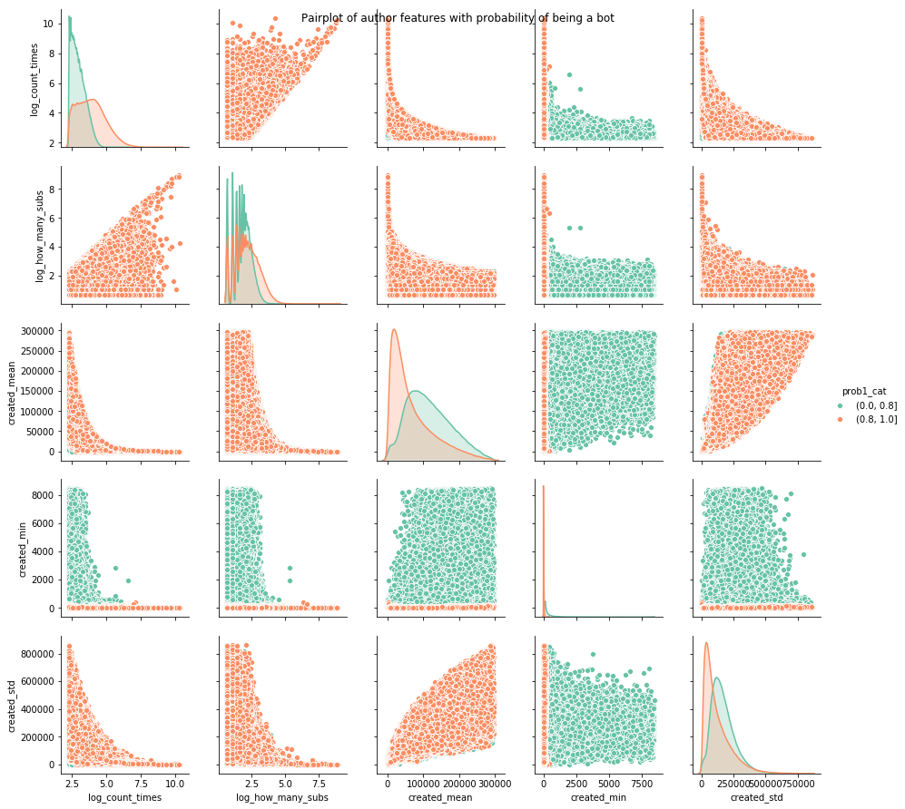

```python
g=sns.pairplot(atleast_10[['log_count_times','log_how_many_subs','created_mean','created_min','created_std','prob1_cat']],hue='prob1_cat',diag_kind='kde', palette=sns.color_palette("Set2"))
g.fig.suptitle("Pairplot of author features with probability of being a bot")
```

### As expected, the number of comments is higher for users with high-confidence of being a bot, however there are some authors that have a lot of comments (e^6.7 ~ 800 comments) where the model doesn't have high confidence of detecting a bot

[figure not shown]

```python
sns.boxplot(data=atleast_10,y='log_count_times', x='prob1_cat')
plt.title("Boxplot for number of log comments for authors vs probability of bot")
```

### The same happens with the subs, all the authors with a high number of subreddits seem to be classified with high confidence as a bot, however some authors that have commented in many subreddits are not classified as bots

[figure not shown]

```python
sns.boxplot(data=atleast_10,y='log_how_many_subs', x='prob1_cat')
plt.title("Boxplot for number of log subreddit count for authors vs probability of bot")
```

### Average of time between posts is lower for bots

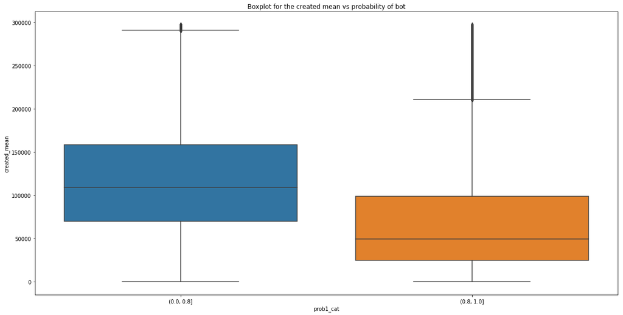

```python
sns.boxplot(data=atleast_10,y='created_mean', x='prob1_cat')
plt.title("Boxplot for the created mean vs probability of bot")
```

### Minimum difference between posts is nearly 0 for bots

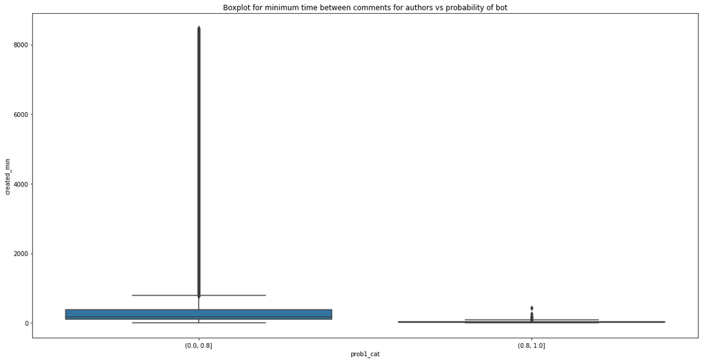

```python
sns.boxplot(data=atleast_10,y='created_min', x='prob1_cat')
plt.title("Boxplot for minimum time between comments for authors vs probability of bot")
```

### Finally, bots seem to be more consistent in their posting rate, having a lower standard deviation than non-bots, which was also expected

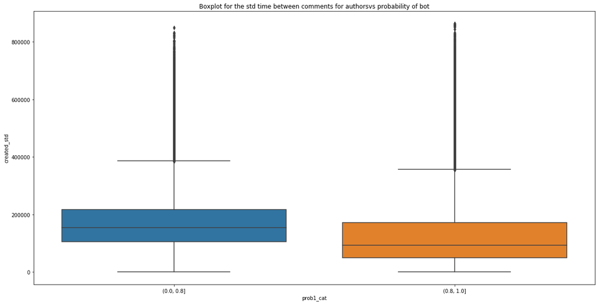

```python
sns.boxplot(data=atleast_10,y='created_std', x='prob1_cat')
plt.title("Boxplot for the std time between comments for authorsvs probability of bot")
```

```python
atleast_10.to_pickle('./data/atleast10_analysis.pickle')
```

### After detecting bots, i'm keeping only interactions from the estimated non-bots for the rest of the analysis.

```python
non_bot_authors=atleast_10.loc[atleast_10.prob_1<.8].index
```

```python
len(non_bot_authors)
```

```
627240
```

```python
df_interactions=df_interactions[df_interactions.author.isin(non_bot_authors)]
```

```python
df_interactions.shape
```

```
(13832144, 3)
```

```python
df_interactions.to_pickle('./data/interactions_final_analysis.pickle')
```

```python
grouped_author=grouped_author[grouped_author.index.isin(non_bot_authors)]
```

```python
grouped_author.shape
```

```
(627240, 11)
```

```python
grouped_author.to_pickle('./data/grouped_author_final.pickle')
```

### Lets compared how the top subreddits in comments have changed after removing the bots. This is a copy of the original top 20 list of most commented subreddits and in the next cell the current count after removing bots and deleted interactions.

- Askreddit and politics keep their importance
- Subreddits such as the_donald,nfl, fantasyfootball dropped some positions
- The askOuija subreddit dropped from the top20 list, this particular subreddit encourages users to make frequent submissions, therefore the model classified them as bots.

```python
df_interactions.subreddit.value_counts().head(20)
```

```
AskReddit            5834042
politics             2208780
nfl                  1285725
The_Donald           1207555
funny                 999457
fantasyfootball       956079
nba                   902452
leagueoflegends       886118
CFB                   882986
worldnews             834164
FortNiteBR            799807
news                  758534
pics                  717980
AskOuija              714345
gaming                693736
Blackops4             606413
soccer                586826
baseball              578326
reddeadredemption     561949
dankmemes             560701
Name: subreddit, dtype: int64
```

```python
df_interactions.subreddit.value_counts().head(20)
```

```
AskReddit          700777
politics           212077
funny              151790
leagueoflegends    106663
gaming             101547
worldnews          101221
pics               101086
The_Donald          82701
news                81865
nfl                 79368
nba                 76780
wow                 75322
FortNiteBR          74243
todayilearned       73828
DestinyTheGame      72214
Blackops4           70237
fantasyfootball     69837
aww                 67670
Showerthoughts      62268
videos              60526
Name: subreddit, dtype: int64
```

### To detect the groups of similar subreddits, I'm going to apply Non-negative matrix factorization to a matrix of size (users * subreddits). The result of the factorization will give us a latent representation of users and items, and since it's non-negative, each dimension in the latent factor coud group similar subreddits.

```python
authors=grouped_author.index
```

```python
main_authors=grouped_author.count_times.nlargest(500).index
```

```python
main_subreddits=df_interactions.subreddit.value_counts().head(500).index
```

```python
co_visitation_group=df_interactions.groupby(['author','subreddit']).agg({'created':lambda x:1})
```

```python
co_visitation_group.head()
```

| author | subreddit | created |
| --- | --- | --- |
| -------------------7 | FreeGamesOnSteam | 1 |
|  | HITsWorthTurkingFor | 1 |
|  | digitalnomad | 1 |
|  | gamedev | 1 |
|  | leanfire | 1 |

```python
co_visitation_unindexed=co_visitation_group.reset_index()
```

```python
co_visitation_unindexed=co_visitation_unindexed.loc[(co_visitation_unindexed.author.isin(main_authors)) & (co_visitation_unindexed.subreddit.isin(main_subreddits)) ]
```

```python
co_visitation_unindexed.head()
```

|  | author | subreddit | created |
| --- | --- | --- | --- |
| 11110 | -reasonable-person- | politics | 1 |
| 43514 | 3lfk1ng | Amd | 1 |
| 43517 | 3lfk1ng | funny | 1 |
| 43518 | 3lfk1ng | interestingasfuck | 1 |
| 43519 | 3lfk1ng | pcgaming | 1 |

### The matrix is sparse and its dense representation wont fit in memory. I will create a dense matrix of the most important users and subreddits in order to show how sparse it is

```python
X=co_visitation_unindexed.pivot(index='author',columns='subreddit',values='created').fillna(0)
```

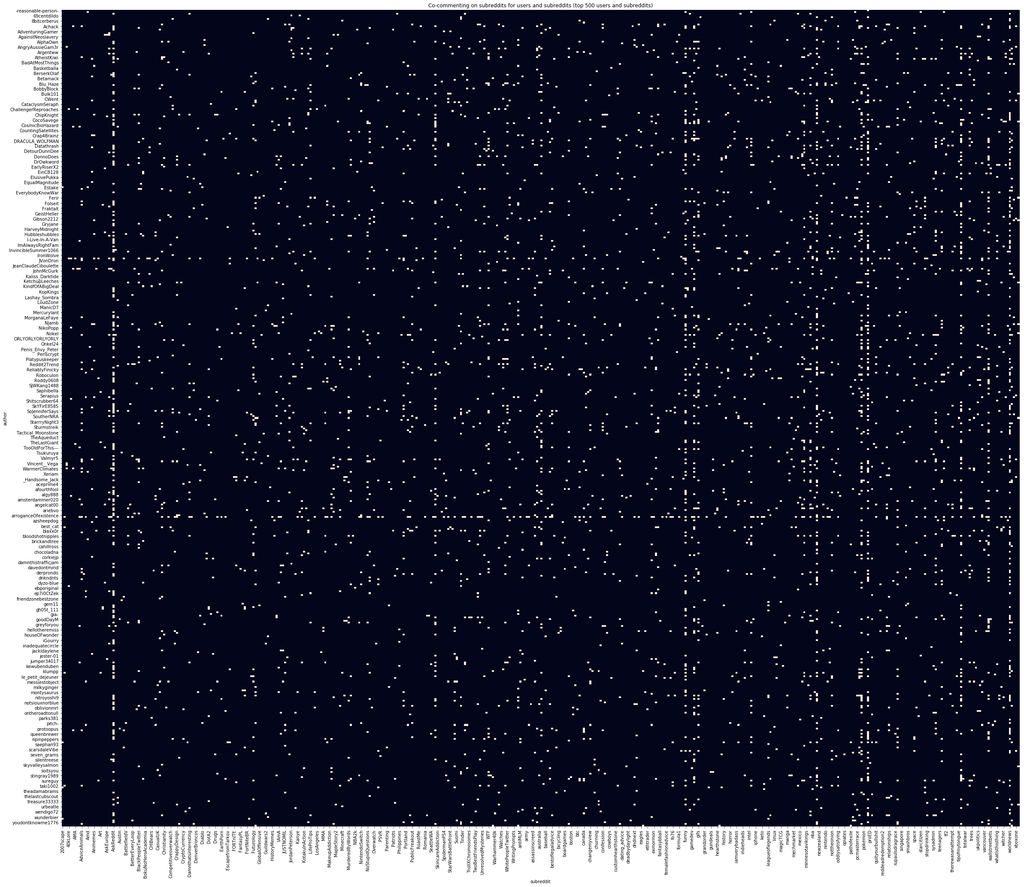

```python
plt.figure(figsize=(40, 35))
ax = plt.axes()
sns.heatmap(X, cbar=False, ax = ax)
ax.set_title("Co-commenting on subreddits for users and subreddits (top 500 users and subreddits)")
plt.show()
```

```python
#Sparse matrix
mat = sps.coo_matrix((co_visitation_group.created, (co_visitation_group.index.labels[0], co_visitation_group.index.labels[1])))
```

```python
mat
```

```
<627240x50416 sparse matrix of type '<class 'numpy.int64'>'
	with 4675377 stored elements in COOrdinate format>
```

```python
from sklearn.decomposition import NMF
model = NMF(n_components=10, init='random', random_state=0, alpha=1, l1_ratio=0)

W = model.fit_transform(mat)
H = model.components_
```

```python
mat.shape
```

```
(627240, 50416)
```

```python
W.shape
```

```
(627240, 10)
```

```python
type(H)
```

```
numpy.ndarray
```

```python
H.shape
```

```
(10, 50416)
```

### W is the latent representation of users, a further analysis could be used to detect by this means groups of users, for example bots or latent groups of analysis

For the time being, I'm going to leave their analysis to future work

```python
df_w=pd.DataFrame(W)
```

```python
df_w['author']=co_visitation_group.index.levels[0]
```

```python
df_h=pd.DataFrame(H.T)
```

```python
df_h.shape
```

```
(50416, 10)
```

```python
df_h['subreddit']=co_visitation_group.index.levels[1]
```

```python
df_h.index=df_h.subreddit
```

```python
del df_h['subreddit']
```

### Variance of each latent component tells us which are the components that govern the factorization. Components 5 and 2 present the biggest variance

```python
df_h.var().sort_values()
```

```
8    0.003231
3    0.003778
0    0.003951
9    0.003961
4    0.004015
1    0.004562
6    0.004746
7    0.004879
2    0.005180
5    0.009595
dtype: float64
```

### The maximum value for component 5 is the askreddit subreddit, which was the most popular one. As we can see, other subreddits oriented to questions have also a large value on their 5th coordinate

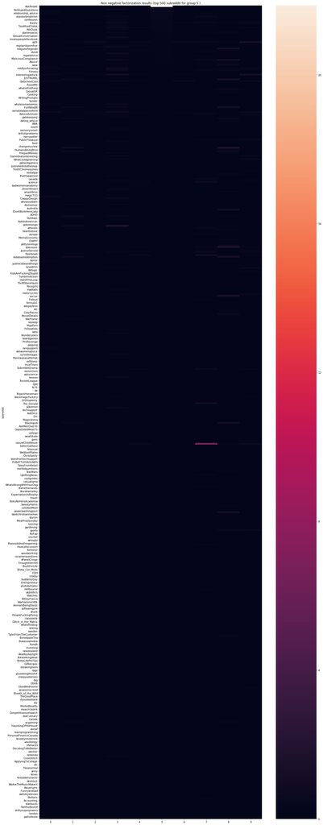

```python
plt.figure(figsize=(20, 60))
ax = plt.axes()
sns.heatmap(df_h[list(range(0,10))].nlargest(500,columns=5),  ax = ax)
ax.set_title("Non negative factorization results (top 500 subreddit for group 5 )")
plt.show();
```

### Funny subreddit has the biggest value for the subreddit, memes and jokes Subreddits with a large value in this coordinate are oriented to show mostly pictures and gifs to users

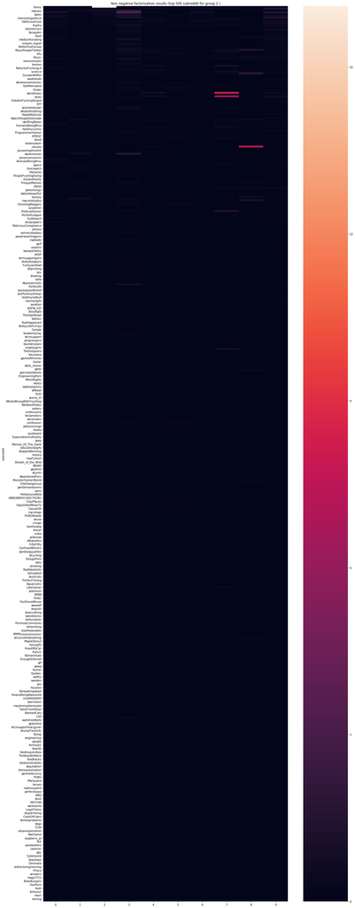

```python
plt.figure(figsize=(20, 60))
ax = plt.axes()
sns.heatmap(df_h[list(range(0,10))].nlargest(500,columns=2),  ax = ax)
ax.set_title("Non negative factorization results (top 500 subreddit for group 2 )")
plt.show();
```

```python
#Final Table
df_results=pd.DataFrame()
```

```python
for i in range(0,10):
    df_results[i]=df_h.sort_values(by=i, ascending=False).head(15).index
```

### This is my interpretation of the resulting groups of subreddits

- Group 0 Animals, cats, feel-good subreddits
- Group 1 Gaming platforms and console/pc games
- Group 2 Humor oriented subreddits
- Group 3 Humor oriented subreddits but oriented to memes and more youth humor
- Group 4 News , technology, science
- Group 5 Conversational oriented subreddits, advice and tips
- Group 6 Too general to give an opinion
- Group 7 Politics, news
- Group 8 Movies, sports and also consoles
- Group 9 Gifs and videos, but its mixed

```python
df_results
```

|  | 0 | 1 | 2 | 3 | 4 | 5 | 6 | 7 | 8 | 9 |
| --- | --- | --- | --- | --- | --- | --- | --- | --- | --- | --- |
| 0 | aww | gaming | funny | Showerthoughts | todayilearned | AskReddit | pics | politics | movies | gifs |
| 1 | mildlyinteresting | PS4 | WTF | mildlyinteresting | worldnews | AskMen | mildlyinteresting | worldnews | nfl | videos |
| 2 | oddlysatisfying | reddeadredemption | memes | dankmemes | news | NoStupidQuestions | WTF | news | nba | mildlyinteresting |
| 3 | trashy | pcmasterrace | mildlyinteresting | memes | WTF | relationships | OldSchoolCool | PoliticalHumor | fantasyfootball | WTF |
| 4 | OldSchoolCool | dankmemes | Jokes | interestingasfuck | technology | relationship_advice | trashy | technology | television | interestingasfuck |
| 5 | interestingasfuck | xboxone | oddlysatisfying | oddlysatisfying | nottheonion | AskWomen | AdviceAnimals | The_Donald | PS4 | news |
| 6 | cats | memes | interestingasfuck | me_irl | OldSchoolCool | unpopularopinion | interestingasfuck | science | baseball | OldSchoolCool |
| 7 | food | NintendoSwitch | AdviceAnimals | mildlyinfuriating | science | personalfinance | food | nottheonion | CFB | oddlysatisfying |
| 8 | relationship_advice | Blackops4 | OldSchoolCool | Jokes | interestingasfuck | confession | BlackPeopleTwitter | Futurology | soccer | Whatcouldgowrong |
| 9 | rarepuppers | wow | Whatcouldgowrong | WhitePeopleTwitter | LifeProTips | ChoosingBeggars | Music | trashy | BlackPeopleTwitter | Unexpected |
| 10 | MadeMeSmile | FortNiteBR | trashy | trashy | explainlikeimfive | trashy | sports | BlackPeopleTwitter | hiphopheads | trashy |
| 11 | NatureIsFuckingLit | Games | Damnthatsinteresting | BlackPeopleTwitter | mildlyinteresting | tifu | movies | unpopularopinion | MMA | Damnthatsinteresting |
| 12 | Eyebleach | Overwatch | IdiotsInCars | NoStupidQuestions | movies | TooAfraidToAsk | nottheonion | canada | reddeadredemption | PublicFreakout |
| 13 | relationships | DestinyTheGame | Unexpected | CrappyDesign | Futurology | LifeProTips | news | WTF | leagueoflegends | sports |
| 14 | Damnthatsinteresting | Rainbow6 | facepalm | teenagers | videos | AskOuija | WhitePeopleTwitter | atheism | xboxone | worldnews |

```python
label_group=df_h.idxmax(axis=1)
```

```python
df_h['label_group']=label_group
```

```python
df_h_top=df_h.loc[main_subreddits]
```

```python
from sklearn.manifold import TSNE
```

```python
tsne = TSNE(n_components=2,
                         random_state=0, perplexity=50)
```

```python
Y = tsne.fit_transform(df_h_top[list(range(0,10))])
```

```python
df_tnse=pd.DataFrame(Y, index=df_h_top.index, columns=['x','y'])
```

```python
df_tnse=df_tnse.join(df_h_top['label_group'])
```

```python
size=np.log10(df_interactions.subreddit.value_counts())
```

```python
df_tnse=df_tnse.join(size)
```

```python
df_tnse.rename(columns={'subreddit':'size'},inplace=True)
```

```python
df_tnse
```

|  | x | y | label_group | size |
| --- | --- | --- | --- | --- |
| AskReddit | 11.429283 | -18.819820 | 5 | 5.845580 |
| politics | 12.246171 | -9.644099 | 7 | 5.326494 |
| funny | 3.758139 | -24.921465 | 2 | 5.181243 |
| leagueoflegends | -0.022528 | 24.288103 | 8 | 5.028014 |
| gaming | -2.422030 | 24.279245 | 1 | 5.006667 |
| worldnews | 12.242488 | -9.651796 | 7 | 5.005271 |
| pics | 3.122672 | -23.856525 | 6 | 5.004691 |
| The_Donald | -2.225563 | -17.196295 | 7 | 4.917511 |
| news | 12.237510 | -9.655412 | 7 | 4.913098 |
| nfl | 1.712426 | 27.080025 | 8 | 4.899645 |
| nba | 1.530942 | 26.893314 | 8 | 4.885248 |
| wow | -1.834041 | 22.101994 | 8 | 4.876922 |
| FortNiteBR | -0.223528 | 23.826834 | 8 | 4.870656 |
| todayilearned | 1.366058 | -24.007116 | 4 | 4.868221 |
| DestinyTheGame | -2.494229 | 21.557737 | 8 | 4.858621 |
| Blackops4 | -0.627601 | 23.975029 | 8 | 4.846566 |
| fantasyfootball | 0.395096 | 26.011709 | 8 | 4.844086 |
| aww | 6.057467 | -24.205549 | 0 | 4.830396 |
| Showerthoughts | 7.969816 | -23.979515 | 3 | 4.794265 |
| videos | -1.564384 | -22.551577 | 9 | 4.781942 |
| reddeadredemption | -1.334925 | 24.271593 | 8 | 4.777615 |
| soccer | 0.295188 | 25.155573 | 8 | 4.754746 |
| CFB | 0.241218 | 25.423553 | 8 | 4.750400 |
| MMA | 0.497081 | 24.649881 | 8 | 4.719141 |
| gifs | -1.568440 | -22.545879 | 9 | 4.709177 |
| dankmemes | 8.205191 | -22.531315 | 3 | 4.702818 |
| movies | 1.827734 | 27.193571 | 8 | 4.671080 |
| memes | 8.141187 | -22.550419 | 3 | 4.635775 |
| SquaredCircle | 0.644526 | 22.284193 | 8 | 4.618257 |
| mildlyinteresting | 7.653680 | -23.779745 | 3 | 4.617964 |
| ... | ... | ... | ... | ... |
| gamedev | -9.146160 | 9.963917 | 1 | 3.702517 |
| thewalkingdead | 0.675112 | 14.596209 | 8 | 3.702086 |
| BravoRealHousewives | 2.192708 | 2.542825 | 5 | 3.701827 |
| progresspics | -4.084477 | -9.287782 | 5 | 3.701827 |
| houston | 1.970616 | -3.757437 | 7 | 3.701482 |
| microgrowery | 0.223911 | 1.889682 | 7 | 3.701395 |
| ethtrader | -0.213277 | 0.894990 | 7 | 3.701309 |
| bestof | 7.196977 | -8.607002 | 7 | 3.700617 |
| xxfitness | 4.322730 | 0.854855 | 5 | 3.700358 |
| DenverBroncos | 2.586555 | 14.148386 | 8 | 3.700098 |
| Piracy | -4.539181 | 9.599601 | 8 | 3.699751 |
| datingoverthirty | 2.416829 | 1.932709 | 5 | 3.699578 |
| TrueOffMyChest | -1.248635 | -10.815243 | 5 | 3.698970 |
| AskRedditAfterDark | -2.307152 | -7.990851 | 5 | 3.698362 |
| Seaofthieves | -6.925231 | 9.341604 | 1 | 3.696968 |
| Entrepreneur | -0.721890 | -2.472760 | 5 | 3.695657 |
| DCcomics | 1.166807 | 13.058998 | 8 | 3.694868 |
| Kaiserreich | -0.637990 | 1.709774 | 7 | 3.692935 |
| ottawa | 0.027214 | 0.218807 | 5 | 3.692759 |
| rugbyunion | -3.935946 | 3.451759 | 8 | 3.692053 |
| CruciblePlaybook | -5.331915 | 6.627285 | 8 | 3.692053 |
| asktrp | 0.377646 | 2.924745 | 5 | 3.690816 |
| gadgets | 5.049455 | -12.301388 | 9 | 3.690196 |
| TopMindsOfReddit | 6.032452 | -7.166326 | 7 | 3.690019 |
| Pathfinder_RPG | -1.920935 | 0.770707 | 5 | 3.689309 |
| indieheads | 1.979697 | 14.357684 | 8 | 3.687975 |
| boston | 3.019698 | -3.533396 | 7 | 3.687351 |
| slatestarcodex | -0.257885 | 2.583993 | 7 | 3.686547 |
| Accounting | -4.271793 | 1.861093 | 8 | 3.685921 |
| youtubehaiku | -0.401152 | 16.457170 | 9 | 3.683317 |

500 rows × 4 columns

```python
palette = d3['Category10'][len(np.unique(df_tnse.label_group))]
```

```python
colors = [palette[x] for x in df_tnse.label_group]
```

```python
source = ColumnDataSource(
        data=dict(
            x=df_tnse['x'],
            y=df_tnse['y'],
            desc=df_tnse.index,
            label=df_tnse.label_group.astype(str),
            colors=colors,
            size=df_tnse['size']*5
        )
    )
```

```python
hover = HoverTool(
        tooltips=[
            ("(x,y)", "($x, $y)"),
             ("group", "@label"),
            ("desc", "@desc"),
        ]
    )
```

```python
p = figure(plot_width=1000, plot_height=1000, tools=[hover,'zoom_in','zoom_out'], title="TNSE projection of subreddits (top 500)")
```

```python
p.scatter('x', 'y', size='size', source=source, fill_color='colors', legend='label',muted_color='colors', muted_alpha=0.2)
p.legend.location = "top_left"
p.legend.click_policy="mute"
```

### Finally, a TNSE projection of the latent non-negative space is visualized for the top 500 communities

Hover over the points to see the which subreddits are.

This is a representation by taking into account all the latent dimensions, closeby subreddits are close on their latent representation.

```python
show(p)
```

[interactive chart not shown]